# Kalman Filter

${\bf \large \cal Hovhannes \ Grigoryan}\\ {\rm \small New \ York, \ NY}$

### Abstract

We describe the theory and the algorithm behind the linear Kalman filter, and write a simple implementation for it. We also implement adaptive Kalman filter that modifies observation covariance matrix based on recent measurements, and asynchronous Kalman filter that processes observations at different rates. We demonstrate applications of Kalman filter for 1D and 2D projectile motions, GPS signal filtering, stock return prediction. Finally, we describe how Kalman filter can be used to perform dynamic linear regression.

### Content

> - *The Linear State Space Model*
> - *The Linear Kalman Filter*
> - *Projectile Motion 1D*
> - *Projectile Motion 2D*
> - *Kalman Filter for Asynchronous Measurements*
> - *Applications to GPS Signals*
> - *Applications to Stock Returns*
> - *Using Kalman Filter for Linear Regression*

```python
%%html

<style>
body, p, div.rendered_html {
    color: black;
    font-family: "Times Roman", sans-serif;
    font-size: 12pt;
}

body {
  background-color: #B8BAC3;
}
</style>
```

```python
import sys, os
import warnings

sys.path.append(os.path.abspath(os.path.join('..')))
warnings.filterwarnings('ignore')

import random
import numpy as np

import matplotlib.pyplot as plt

from utils.html_converter import html_converter

%precision 20
%matplotlib inline
%config InlineBackend.figure_format = 'retina'

plt.rcParams['figure.figsize'] = (14,8)
plt.style.use('fivethirtyeight')
```

# The Linear State Space Model

The main ingredients of a discrete, linear, time-varying (Gaussian-Markov, standard second-order) state space model are:

- $n \times 1$ state vector $x_t \in \mathbb{R}^n$ denoting at time $t = 0, 1, 2, \dots$
- $n \times n$ transition matrix $A \in \mathbb{R}^{n \times n}$
- $n \times n$ state noise covariance matrix $Q \in \mathbb{R}^{n \times n}$
- $n \times 1$ state noise vectors $w_t \in \mathbb{R}^{n}$, such that $w_t \sim N(0, Q)$
- $k \times 1$ observation vector $y_t \in \mathbb{R}^{k}$ at time $t = 0, 1, 2, \dots$
- $k \times n$ measurement matrix $G \in \mathbb{R}^{k \times n}$
- $k \times k$ observation noise covariance matrix $R \in \mathbb{R}^{k \times k}$
- $k \times 1$ observation noise vector $v_t \in \mathbb{R}^{k}$, such that $v_t \sim N(0, R)$

Here is the linear state-space system

- **Initial Distribution:** $x_0 \sim p(x_0) = N(x_0; \hat{x}_0, \Sigma_0)$
- **Dynamic Model:** $x_{t} = A x_{t-1} + w_{t} \sim p(x_t|x_{t-1}) = N(x_t; A \hat{x}_{t-1}, A\Sigma_{t-1}A^T + Q)$
- **Measurement Model:** $y_t = G x_t + v_t \sim p(y_t|x_t) = N(y_t; G \hat{x}_t, G\Sigma_{t}G^T + R)$

Matrices $A, Q, G, R$ determine the probability distributions of $\{x_t\}$ and $\{y_t\}$, while $x_0$ and $w_t/v_t$ pin down the values of these sequences.

### Type of Distributions

- **Filtering Distribution:** $p(x_t | y_{1:t}) $, where $t = 1, 2, \dots, T$
- **Smoothing Distribution:** $p(x_t | y_{1:T}) $, where $t = 1, 2, \dots, T$
- **Prediction Distribution:** $p(x_{t+\tau} | y_{1:t}) $, where $t = 1, 2, \dots, T$ and $\tau = 1, 2, \dots $

### Bayesian Filtering

- **Initialization:** The recursive step starts from the prior distribution $p(x_0)$
- **Prediction Step:** *Chapman-Kolmogorov equation* $p(x_t | y_{1:t-1}) = \int p(x_t | x_{t-1}) p(x_{t-1} | y_{1:t-1})~\text{d}x_{t-1} $
- **Update Step:** *Bayes' rule* $p(x_{t}|y_{1:t}) = \frac{p(y_t | x_{t}) p(x_{t} | y_{1:t-1})}{\int p(y_t | x_t) p(x_t | y_{1:t-1}) ~\text{d}x_{t}} $

# The Linear Kalman Filter

The purpose of filtering is to extract the required information from a signal, ignoring everything else. More quantitatively, the goal of a filter is to find a state estimate, $\hat{x}_t$, that maximizes the probability or likelihood of measurement $y_t$, that is $\max[\Pi_t p(y_t|\hat{x}_t)]$. Kalman filter (Kalman '60) is a solution to the Bayesian filtering equations, where the dynamic and measurement models are linear Gaussian.

Consider Markovian dynamics for the state variable $x_t$ satisfying the following linear **state equation**:

$$x_{t} = A_t x_{t-1} + B_t u_t + w_{t}, \ \ \text{where} \ \ w_t \sim N(0, Q) ,$$

$A_t$ is the state transition matrix, $B_t$ is the control-input matrix, $u_t$ is the control vector, and $w_t$ is the process noise. We also assume Gaussian prior for the state variable:

$$p(x_t) = N(x_t; \hat{x}_t, \Sigma_t), \ \ \text{where} \ \ \Sigma_t = \mathbb{E}[(x_t - \hat{x}_t )(x_t - \hat{x}_t)^T].$$

In linear Gaussian Kalman process, the observation is described by the following **measurement equation**:

$$y_t = G_t x_t + v_t, \ \ \text{where} \ \ v_t \sim N(0, R),$$

$y_t$ is the measurement vector, $G_t$ is the observation matrix, $v_t$ is the observation noise.

Assume $\hat{x}^{-}_t$ is the *a priori* estimate with knowledge about the process prior time $t$, and $\hat{x}_t$ is the *a posteriori* state estimate including the measurement $y_t$. The update equation can be written in the following general form:

$$ \hat{x}_t = \hat{x}^{-}_t + K_t (y_t - G \hat{x}^{-}_t), $$

where $K_t$ is the optimal Kalman gain at time $t$. The form of $K_t$ can be derived by minimizing the the mean square error (MSE).

## Finding Optimal Kalman Gain

To derive the Kalman gain, we rewrite the above equation as:

$$ \hat{x}_t = \hat{x}^{-}_t + K_t (G x_t + v_t - G \hat{x}^{-}_t), $$

and taking into account that $\Sigma_t = \mathbb{E}[(x_t - \hat{x}_t )(x_t - \hat{x}_t)^T]$, we will get the error covariance update equation:

$$ \Sigma_t = (\mathbb{1} - K_t G)\Sigma^-_t (\mathbb{1} - K_t G)^T + K_t R K_t^T. $$

Since the trace of the error covariance matrix is the sum of the MSE, to minimize MSE, we need to minimize $\text{Tr}(\Sigma_t)$. More explicitly, the trace can be written as:

$$ \text{Tr}(\Sigma_t) = \text{Tr}(\Sigma_t^-) - 2\text{Tr}(K_t G \Sigma_t^-) + \text{Tr}(K_t(G \Sigma_t^- G^T + R)K_t^T).$$

Differentiating w.r.t. $K_t$, and equating to zero, we get:

$$ d\text{Tr}(\Sigma_t)/d K_t = - 2 \Sigma_t^-G^T + 2 K_t(G \Sigma_t^- G^T + R) = 0 $$

Therefore, solving for $K_t$, we get:

$$K_t = \Sigma^-_t G^T (G \Sigma^-_t G^T + R)^{-1}.$$

This is not the only way to get $K_t$. The expression for the Kalman gain emerges quite naturally when we work with distributions, and use the properties of conditional multivariate Gaussian distributions.

## Prediction-Correction Loop

**Time Update (prediction):** Find the estimate and the error covariance at time $t$, given the state and error covariance at $t-1$:

- $\hat{x}^{-}_t = A_t\hat{x}_{t-1} + B_t u_t$
- $\Sigma^-_t = A_t \Sigma_{t-1} A_t^T + Q_t$

These are clearly the moments of a predicted Gaussian distribution, $p(x_{t} | y_{1:t-1})$, given that $x_{t-1} \sim N(\hat{x}_{t-1}, \Sigma_{t-1})$.

**Measurement Update (correction):** Given the measurement at time $t$, update the state $\hat{x}^{-}_t$ and $\Sigma^-_t$,

- $K_t = \Sigma^-_t G^T_t (G_t \Sigma^-_t G^T_t + R_t)^{-1}$
- $ \hat{x}_t = \hat{x}^{-}_t + K_t (y_t - G_t \hat{x}^{-}_t), $
- $\Sigma_{t} = \left(\mathbb{1} - K_t G_t\right)\Sigma^-_t $

The corrected moments are obtained using *Bayes' rule*, from the update step of Bayesian Filtering:

$$p(x_{t}|y_{1:t}) = \frac{p(y_t | x_{t}) p(x_{t} | y_{1:t-1})}{\int p(y_t | x_t) p(x_t | y_{1:t-1}) ~\text{d}x_{t}} $$

and *measurement model*,

$$y_t = G_t x_t \sim p(y_t|x_t) = N(y_t; G_t \hat{x}^-_t, R_t).$$

Since we assumed Markovian dynamics,

$$ p(x_{t} | y_{1:t-1}) = p(x_{t}^-) = N(x_{t}^-; \hat{x}_{t}^-, \Sigma_{t}^-)$$

is a prior distribution, while

$$p(x_{t}|y_{1:t})=p(x_t|y_t) = N(x_t; \hat{x}_{t}, \Sigma_{t})$$

is a posterior distribution. Since, the denominator in a Bayes' rule is essentially a normalizing constant, and the product of Gaussian distributions is also a Gaussian, we arrive to the above prescription for the "correction" step.

## Summary

**Forecasting/Time Update/Prediction Step:** In this step, we want to find the predictive distribution

$$p(x_{t| t-1}) = N(x_{t}; \hat{x}_{t|t-1}, \Sigma_{t|t-1})$$

From the dynamics of state space variable $x_t$, we have:

$$\hat{x}_{t | t-1} = A_t \hat{x}_{t-1|t-1} + B_t u_t$$$$\Sigma_{t| t-1} = A_t \Sigma_{t-1| t-1} A^T_t + Q_t $$

**Filtering/Measurement Update/Correction Step:** In this step, we update the prior after observing the data, $y_t$,

$$p(x_{t | t}) = N(x_{t | t}; \hat{x}_{t | t}, \Sigma_{t | t})$$$$K_t = \Sigma_{t| t-1} G^T_t (G_t \Sigma_{t| t-1} G^T_t + R_t)^{-1}$$$$\hat{x}_{t|t} = \hat{x}_{t|t-1} + K_t (y_t - G_t\hat{x}_{t|t-1}) $$$$\Sigma_{t | t} = (\mathbb{1} - K_t G_t) \Sigma_{t|t-1} $$

where $\hat{x}_{t|t}$ is the a posteriori state estimate at time $t$ given observations up to and including at time $t$, and $\Sigma_{t|t}$ is the a posteriori error covariance matrix (a measure of the estimated accuracy of the state estimate). Also, $y_t - G_t\hat{x}_{t|t-1}$ is called innovation residual, and $G_t \Sigma_{t|t-1} G^T_t + R_t$ is innovation covariance.

If the state and observation noise processes are not stationary then we need to infer the variances. This can be done by using, e.g., causal re-estimation method (Jazwinski), or effective but acausal EM based methods, or variational Bayes approach.

## Plain Kalman Filter: Simple Working Implementation

```python
class PlainKalmanFilter(object):
    """ Kalman Filter.
            > x_{t} = A x_{t-1} + B_{t} u_{t} + w_{t}, where w_t ~ N(0, Q)
            > y_t = G x_t + v_t, where v_t ~ N(0, R)
    params::
        x: [n_states, 1] initial state mean
    Sigma: [n_states, n_states] initial state covariance matrix
        A: [n_states, n_states] state transition matrix
        Q: [n_states, n_states] transition covariance matrix
        B: [n_states, n_u] control matrix
        u: [n_u, 1] control vector
        y: [n_obs, 1] (single) observation
        G: [n_obs, n_states] measurement/observation matrix
        R: [n_obs, n_obs] observation covariance matrix
    """
    def __init__(self, x, Sigma, A, G, Q, R, B=None, u=None):
        self.x = x
        self.Sigma = Sigma
        self.A = A
        self.G = G
        self.Q = Q
        self.R = R
        self.B = B
        self.u = u
        self.n_states = None
        self.n_obs = None
        self.offset = None
        self._initialize()

    def _initialize(self):
        n = self.A.shape[0]
        k = self.G.shape[0]
        self.n_states = n
        self.n_obs = k
        assert (self.x.shape == (n, 1))
        assert (self.Sigma.shape == (n, n))
        assert (self.A.shape[1] == n)
        assert (self.G.shape[1] == n)
        assert (self.Q.shape == (n, n))
        assert (self.R.shape == (k, k))
        if self.B is not None and self.u is not None:
            self.offset = np.dot(self.B, self.u)
            assert(self.offset.shape == (n, 1))

    def predict_next_state(self, x, Sigma):
        """ Predicts next prior moments (x, Sigma) based on previous moments."""
        assert (x.shape == (self.n_states, 1))
        assert (Sigma.shape == (self.n_states, self.n_states))
        if self.offset is not None:
            xp = np.dot(self.A, x) + self.offset
        else:
            xp = np.dot(self.A, x)
        Sigmap = np.dot(self.A, np.dot(Sigma, self.A.T)) + self.Q
        return xp, Sigmap

    def predict_observation(self, x, Sigma):
        """ Finds E[y], Cov[y], given (x, Sigma)"""
        assert (x.shape == (self.n_states, 1))
        assert (Sigma.shape == (self.n_states, self.n_states))
        obs_mean = np.dot(self.G, x)
        obs_cov = np.dot(self.G, np.dot(Sigma, self.G.T)) + self.R
        return obs_mean, obs_cov

    def filter_state(self, y, x, Sigma):
        """ Updates/filters (x, Sigma) to posterior moments based on a current single measurement y_t."""
        assert (y.shape == (self.n_obs, 1))
        assert (x.shape == (self.n_states, 1))
        assert (Sigma.shape == (self.n_states, self.n_states))
        z = y - np.dot(self.G, x)                              # innovation or observation residual
        S = np.dot(self.G, np.dot(Sigma, self.G.T)) + self.R   # innovation or residual covariance
        SI = np.linalg.pinv(S)
        K = np.dot(Sigma, np.dot(self.G.T, SI))                # optimal Kalman gain
        x_post = x + np.dot(K, z)                              # updated (a posteriori) state estimate
        Sigma_post = Sigma - np.dot(K, np.dot(self.G, Sigma))  # updated (a posteriori) covariance estimate
        return x_post, Sigma_post

    def filter(self, y, order="predict_filter"):
        """ Performs sequential state update followed by measurement update.
        Returns all {x_t}, {Sigma_t} given data {y_t}."""
        assert (y.shape[0] == self.n_obs)
        means = []
        covs = []
        xp, Sigmap = self.x, self.Sigma
        for yi in y.T:
            obs = np.atleast_2d(yi).reshape(self.n_obs, 1)
            if order=="predict_filter":
                xp, Sigmap = self.predict_next_state(xp, Sigmap)
                xp, Sigmap = self.filter_state(obs, xp, Sigmap)
            elif order=="filter_predict":
                # This is experimental
                xp, Sigmap = self.filter_state(obs, xp, Sigmap)
                xp, Sigmap = self.predict_next_state(xp, Sigmap)
            means.append(xp)
            covs.append(Sigmap)
        return np.array(means), np.array(covs)

    def smooth_next(self, x, Sigma, next_x, next_Sigma):
        """ Kalman smoother backwards step. Takes posterior moments (x, Sigma)
            and (next_x, next_Sigma) to return smoothed moments.
            params:
                x: posterior mean E[x_j|y_1...y_j],
                Sigma: posterior covariance Cov[x_j|y_1...y_j],
                next_x: E[x_{j+1}|y_1...y_T]
                next_Sigma: Cov[x_{j+1}|y_1...y_T]
            return:
                smoothed mean: E[x_j|y_1...y_T],
                smoothed covariance: Cov[x_j|y_1...y_T]
        """
        assert (x.shape == (self.n_states, 1))
        assert (Sigma.shape == (self.n_states, self.n_states))
        assert(next_x.shape == (self.n_states, 1))
        assert(next_Sigma.shape == (self.n_states, self.n_states))
        xp, Sigmap = self.predict_next_state(x, Sigma)
        C = np.dot(Sigma, np.dot(self.A.T, np.linalg.pinv(Sigmap)))  # Kalman smoothing gain
        smooth_mean = x + np.dot(C, (next_x - xp))
        smooth_covariance = Sigma + np.dot(C, np.dot((next_Sigma - Sigmap), C.T))
        return smooth_mean, smooth_covariance

    def smooth(self, y):
        means, covs = self.filter(y)
        n_data = y.shape[1]
        xs = means[-1, :, :]
        Sigmas = covs[-1, :, :]
        smoothed_means, smoothed_covs = [xs], [Sigmas]
        for j in range(n_data)[-2::-1]:
            x = means[j, :, :]
            Sigma = covs[j, :, :]
            xs, Sigmas = self.smooth_next(x, Sigma, xs, Sigmas)
            smoothed_means.append(xs)
            smoothed_covs.append(Sigmas)
        return np.array(smoothed_means)[::-1], np.array(smoothed_covs)[::-1]

    def forecast(self, y, n_steps):
        """ Forecasts or sample state/observation means and covariances n_steps time steps ahead."""
        assert(n_steps > 0)
        means, covs = self.filter(y)
        xp, Sigmap = means[-1], covs[-1]
        pred_state_means, pred_state_covs = [], []
        pred_obs_means, pred_obs_covs = [], []
        for _ in range(n_steps):
            xp, Sigmap = self.predict_next_state(xp, Sigmap)
            pred_state_means.append(xp)
            pred_state_covs.append(Sigmap)
            obs_mean, obs_cov = self.predict_observation(xp, Sigmap)
            pred_obs_means.append(obs_mean)
            pred_obs_covs.append(obs_cov)
        return np.array(pred_state_means), np.array(pred_state_covs), \
               np.array(pred_obs_means), np.array(pred_obs_covs)

    def __str__(self):
        if self.B is not None and self.u is not None:
            Bu = f", B[{self.B.shape}], u[{self.u.shape}]"
        else:
            Bu = ""
        name = f"{type(self).__name__}(x[{self.x.shape}], Sigma[{self.Sigma.shape}], "
        name += f"A[{self.A.shape}], G[{self.G.shape}], Q[{self.Q.shape}], R[{self.R.shape}]{Bu})"
        return name
```

```python
class AdaptiveKalman(PlainKalmanFilter):
    """Simple Adaptive Kalman filter that adjust R (measurement noise covariance matrix)
       based on rolling measurement data covariance. """
    def __init__(self, x, Sigma, A, G, Q, R, B=None, u=None, window=10):
        super().__init__(x, Sigma, A, G, Q, R, B, u)
        self.window = window
        self.Rold = self.R.copy()

    def filter(self, y):
        """ Performs sequential state update followed by measurement update.
        Updates [R], on a rolling [window] interval.
        Returns all {x_t}, {Sigma_t} given data {y_t}."""
        assert (y.shape[0] == self.n_obs)
        assert (y.shape[1] > self.window)
        means = []
        covs = []
        xp, Sigmap = self.x, self.Sigma
        for i, yi in enumerate(y.T):
            obs = np.atleast_2d(yi).reshape(self.n_obs, 1)
            xp, Sigmap = self.predict_next_state(xp, Sigmap)
            xp, Sigmap = self.filter_state(obs, xp, Sigmap)
            means.append(xp)
            covs.append(Sigmap)
            if i > self.window:
                rolling_vars = np.std(y[:, (i-self.window):i], axis=1) ** 2
                self.R  = np.diag(rolling_vars).reshape(self.R.shape)
        self.R = self.Rold
        return np.array(means), np.array(covs)
```

## Test: Constant scalar hidden state

- State dynamics: $x_{t+1} = x_t$, therefore, $A=1$ , $Q=0$ and $x_0=\theta$
- Measurement equation: $y_t = G\theta + v_t$, $ v_t \sim N(0,R)$, where $G=R=1$

Assume $\theta = 11$, $\hat{x}_0 = 6$, $\Sigma_0 = 7$

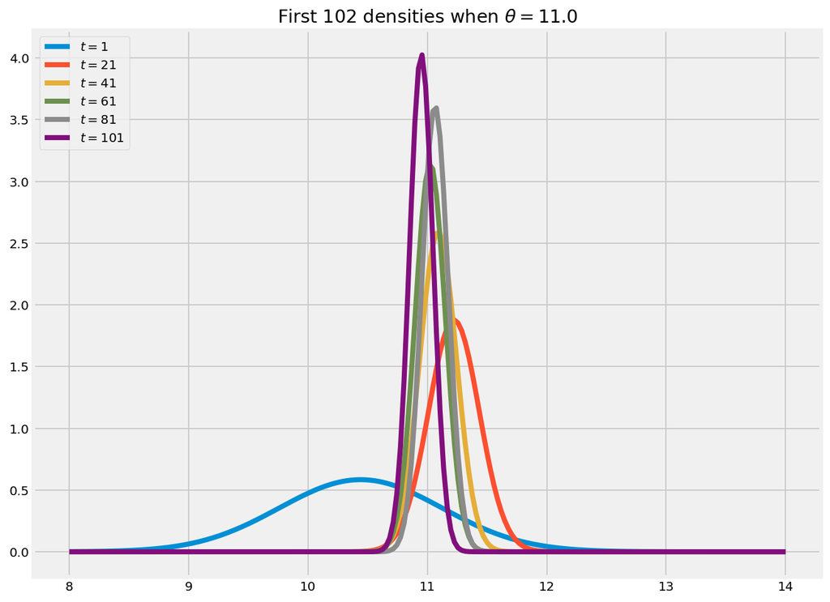

```python
from scipy.stats import norm

theta = 11  # state x_t
A, Q, G, R = list(map(lambda x: np.matrix([x]), [1, 0, 1, 1]))
x_hat, Sigma = np.atleast_2d(6), np.atleast_2d(7)

N = 102
y = theta + np.random.randn(N)

fig, ax = plt.subplots(figsize=(10,8))
xgrid = np.linspace(theta - 3, theta + 3, 200)

pkf = PlainKalmanFilter(np.atleast_2d(x_hat), np.atleast_2d(Sigma), A, G, Q, R)

for i in range(N):
    x_hat, Sigma = pkf.filter_state(np.atleast_2d(y[i]), x_hat, Sigma)
    if i % 20 == 1:
        ax.plot(xgrid, norm.pdf(xgrid, loc=x_hat, scale=np.sqrt(Sigma)).T, label=f'$t={i}$')


ax.set_title(f'First {N} densities when $\\theta = {theta:.1f}$')
ax.legend(loc='upper left')
plt.show()
```

We can observe how our prior distribution converges to expected mean after successive iterations.

# Projectile Motion 1D

### Initializing the problem

Our state will be: $x_t = (x, \dot{x})^T$, and state evolution will be governed by:

$$x_{t} = A x_{t-1} + B_{t} a_{t},$$

where $a_t \sim N(a, \sigma^2_a)$ is noisy acceleration, such that $w_t = B_{t}(a_{t}-a)$, and

$$ A = \begin{bmatrix} 1 & dt \\ 0 & 1 \end{bmatrix}, \ \ B = \begin{bmatrix} \frac{1}{2}dt^2 \\ dt \end{bmatrix}, \ \ Q = BB^T \sigma^2_a = \begin{bmatrix} \frac{1}{4}dt^4 & \frac{1}{2}dt^3 \\ \frac{1}{2}dt^3 & dt^2 \end{bmatrix} \sigma^2_a, \ \ $$

The detector will measure position only, and our noisy measurement will be described by:

$$ y_t = G x_t + v_t,$$

where $v_t \sim N(0, \sigma^2_x)$, and

$$ G = \begin{bmatrix} 1 & 0 \end{bmatrix}, \ \ R = \begin{bmatrix} \sigma^2_x \end{bmatrix}. $$

The initial (prior) state mean and state covariance will be chosen to be:

$$ \hat{x}_{0|0} = \begin{bmatrix} 0.1 \\ 0.1 \end{bmatrix}, \ \ \Sigma_{0|0} = \begin{bmatrix} \sigma^2_x & 0 \\ 0 & \sigma^2_x \end{bmatrix}. $$

```python
dt = 0.1
a = 1.0
sigma_a = 1.0
sigma_x = 3.0

# transition matrix
A = np.array([[1, dt],
              [0, 1]])

# transition covariance matrix
Q = np.array([[0.25 * dt ** 4, 0.5 * dt ** 3],
              [0.5 * dt ** 3, dt ** 2]]) * sigma_a ** 2

G = np.array([[1.0, 0.0]])
R = np.array([[1.0]]) * sigma_x ** 2


# control matrix/vector
B = np.array([[0.5 * dt ** 2],
              [dt]])

# control vector/scalar
u = a * np.array([[1.0]])

x_0 = np.array([[0.1],
                [0.1]])

Sigma_0 = np.array([[sigma_x ** 2, 0.0],
                     [0.0, sigma_x ** 2]])
```

### Simulating Noisy Data

```python
t_max = 10
N = int(t_max / dt)
x0 = 0.0
v0 = 1.0

t = np.linspace(0.0, t_max, N)
true_x = x0 + v0 * t + 0.5 * a * t ** 2
true_v = v0 + a * t
true = [true_x, true_v]

jumps = np.random.poisson(0.9, N)
noise = sigma_x * np.random.random(N)
observed_x = true_x + noise  # + jumps
y = observed_x.reshape(1, N)
```

N.B. One can show that significant deviations from Gaussian distribution (e.g. when adding Poisson jumps) reduce the usefulness of discussed linear Kalman filter.

### Filtering/Smoothing/Forecasting

```python
pkf = PlainKalmanFilter(x_0, Sigma_0, A, G, Q, R, B, u)
print(pkf)

xc, Sigmac = x_0, Sigma_0
means, covs = pkf.filter(y)

#############################################################################

smeans, scovs = pkf.smooth(y)

#############################################################################

n_steps = 50
fsmeans, fscovs, fomean, focovs = pkf.forecast(y, n_steps)

#############################################################################

akf = AdaptiveKalman(x_0, Sigma_0, A, G, Q, R, B, u, window=20)
admeans, adcovs = akf.filter(y)
adsmeans, adscovs = akf.smooth(y)
adfsmeans, adfscovs, adfomean, adfocovs = akf.forecast(y, n_steps)
```

```
PlainKalmanFilter(x[(2, 1)], Sigma[(2, 2)], A[(2, 2)], G[(1, 2)], Q[(2, 2)], R[(1, 1)], B[(2, 1)], u[(1, 1)])
```

```python
def plot_kalman(means, covs, forecasted_means, forecasted_covs, true, num_sigmas, ax, title):
    N = means.shape[0]
    new_means = np.vstack([means, forecasted_means])
    new_stds = np.sqrt(np.hstack([covs, forecasted_covs]))
    new_t = np.arange(N + forecasted_means.shape[0])
    state_var = new_means.ravel()
    stds = new_stds.ravel()
    ax.plot(new_t, state_var, 'b', linewidth=1.5, label="kalman")
    ax.plot(new_t, state_var + num_sigmas * stds, 'k--', linewidth=0.8, label=f"{num_sigmas}-$\sigma$ band")
    ax.plot(new_t, state_var - num_sigmas * stds, 'k--', linewidth=0.8)
    ax.fill_between(new_t, state_var - num_sigmas * stds, state_var + 2 * stds, facecolor='green',
                    interpolate=True, alpha=0.5)
    ax.plot(new_t[:N], true, 'r-', linewidth=1.5, label="true data")
    ax.axvline(x=N, color='black', linewidth=0.8)
    ax.set_title(title)
    ax.legend(loc="best")
    ax.fill_between(new_t, 1.1*min(state_var - num_sigmas * stds), 1.1*max(state_var + num_sigmas * stds),
                    where=new_t>=N,  facecolor='yellow', alpha=0.1)
```

### Filtered and Predicted Data

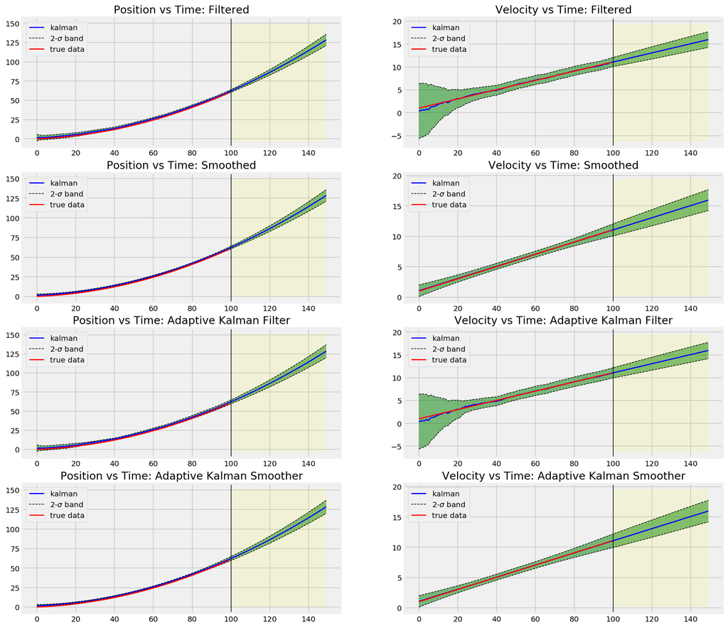

```python
fig = plt.figure(figsize=(15,30))

j = 0
j1 = 1
ax1 = fig.add_subplot(8, 2, 1)
plot_kalman(means[:, j, :], covs[:, j, j], fsmeans[:, j, :], fscovs[:, j, j], true[j], num_sigmas=2,
            ax=ax1, title="Position vs Time: Filtered")

ax2 = fig.add_subplot(8, 2, 2)
plot_kalman(means[:, j1, :], covs[:, j1, j1], fsmeans[:, j1, :], fscovs[:, j1, j1], true[j1], num_sigmas=2,
            ax=ax2, title="Velocity vs Time: Filtered")

ax3 = fig.add_subplot(8, 2, 3)
plot_kalman(smeans[:, j, :], scovs[:, j, j], fsmeans[:, j, :], fscovs[:, j, j], true[j], num_sigmas=2,
            ax=ax3, title="Position vs Time: Smoothed")

ax4 = fig.add_subplot(8, 2, 4)
plot_kalman(smeans[:, j1, :], scovs[:, j1, j1], fsmeans[:, j1, :], fscovs[:, j1, j1], true[j1], num_sigmas=2,
            ax=ax4, title="Velocity vs Time: Smoothed")

ax5 = fig.add_subplot(8, 2, 5)
plot_kalman(admeans[:, j, :], adcovs[:, j, j], adfsmeans[:, j, :], adfscovs[:, j, j], true[j], num_sigmas=2,
            ax=ax5, title="Position vs Time: Adaptive Kalman Filter")

ax6 = fig.add_subplot(8, 2, 6)
plot_kalman(admeans[:, j1, :], adcovs[:, j1, j1], adfsmeans[:, j1, :], adfscovs[:, j1, j1], true[j1], num_sigmas=2,
            ax=ax6, title="Velocity vs Time: Adaptive Kalman Filter")

ax7 = fig.add_subplot(8, 2, 7)
plot_kalman(adsmeans[:, j, :], adscovs[:, j, j], adfsmeans[:, j, :], adfscovs[:, j, j], true[j], num_sigmas=2,
            ax=ax7, title="Position vs Time: Adaptive Kalman Smoother")

ax8 = fig.add_subplot(8, 2, 8)
plot_kalman(adsmeans[:, j1, :], adscovs[:, j1, j1], adfsmeans[:, j1, :], adfscovs[:, j1, j1], true[j1], num_sigmas=2,
            ax=ax8, title="Velocity vs Time: Adaptive Kalman Smoother")

plt.show()
```

## Appendix: Comparisons

```python
from pykalman import KalmanFilter

kf = KalmanFilter(n_dim_obs=1, n_dim_state=2,
                  initial_state_mean=x_0.T.tolist()[0],
                  initial_state_covariance=Sigmac,
                  transition_matrices=A,
                  observation_matrices=G,
                  observation_covariance=R,
                  transition_covariance=Q,
                  transition_offsets=[0.5 * a * dt ** 2, a * dt]
                 )

filtered_state_means, filtered_state_covs = kf.filter(y)
smoothed_state_means, smoothed_state_covs = kf.smooth(y)

#############################################################################

kf_em = KalmanFilter(transition_matrices=A, observation_matrices=G)
kf_em = kf_em.em(y, n_iter=20)

filtered_state_means_em, _ = kf_em.filter(y)
smoothed_state_means_em, _ = kf_em.smooth(y)

future_states, _ = kf.sample(n_steps, initial_state=filtered_state_means[-1])

kf_em.em_vars
```

```
['transition_covariance',
 'observation_covariance',
 'initial_state_mean',
 'initial_state_covariance']
```

### Comparing forecasts of PyKalman and PlainKalman

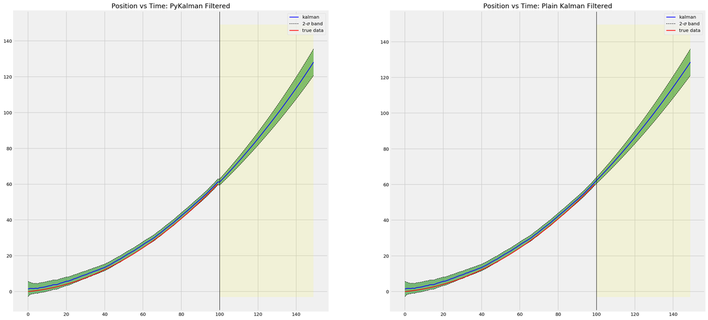

```python
fig = plt.figure(figsize=(24,12))

j = 0
ax1 = fig.add_subplot(1, 2, 1)
plot_kalman(filtered_state_means[:, j].reshape(-1,1), filtered_state_covs[:, j, j], future_states[:, j].reshape(-1,1), fscovs[:, j, j], true[j], num_sigmas=2,
            ax=ax1, title="Position vs Time: PyKalman Filtered")

ax2 = fig.add_subplot(1, 2, 2)
plot_kalman(means[:, j, :], covs[:, j, j], fsmeans[:,j,:], fscovs[:, j, j], true[j], num_sigmas=2,
            ax=ax2, title="Position vs Time: Plain Kalman Filtered")
```

### Comparison of coordinates and velocities for various filters

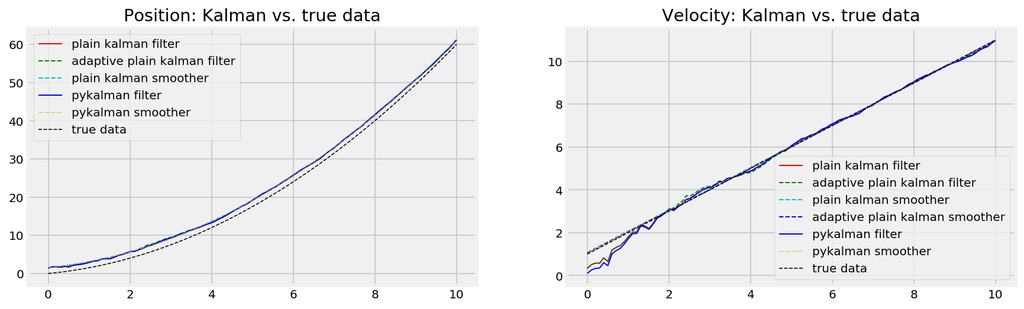

```python
fig = plt.figure(figsize=plt.figaspect(0.3))

ax = fig.add_subplot(1, 2, 1)
ax.plot(t, means[:, 0], 'r-', linewidth=1.0, label="plain kalman filter")
ax.plot(t, admeans[:, 0], 'g--', linewidth=1.0, label="adaptive plain kalman filter")
ax.plot(t, smeans[:, 0], 'c--', linewidth=1.0, label="plain kalman smoother")
ax.plot(t, filtered_state_means[:, 0], 'b-', linewidth=1.0, label="pykalman filter")
# ax.plot(t, filtered_state_means_em[:,0], 'g-', linewidth=1.0, label="pykalman_em filter")

ax.plot(t, smoothed_state_means[:, 0], 'y-.', linewidth=0.5, label="pykalman smoother")
# ax.plot(t, smoothed_state_means_em[:,0], 'c-.', linewidth=0.5, label="pykalman_em smoother")

ax.plot(t, true_x, 'k--', linewidth=0.8, label="true data")
ax.legend(loc="best")
ax.set_title("Position: Kalman vs. true data")

ax2 = fig.add_subplot(1, 2, 2)
ax2.plot(t, means[:, 1], 'r-', linewidth=1.0, label="plain kalman filter")
ax2.plot(t, admeans[:, 1], 'g--', linewidth=1.0, label="adaptive plain kalman filter")
ax2.plot(t, smeans[:, 1], 'c--', linewidth=1.0, label="plain kalman smoother")
ax2.plot(t, adsmeans[:, 1], 'b--', linewidth=1.0, label="adaptive plain kalman smoother")
ax2.plot(t, filtered_state_means[:, 1], 'b-', linewidth=1.0, label="pykalman filter")
# ax2.plot(t, filtered_state_means_em[:,1], 'g-', linewidth=1.0, label="pykalman_em filter")

ax2.plot(t, smoothed_state_means[:, 1], 'y-.', linewidth=0.5, label="pykalman smoother")
# ax2.plot(t, smoothed_state_means_em[:,1], 'c-.', linewidth=0.5, label="pykalman_em smoother")

ax2.plot(t, true_v, 'k--', linewidth=0.8, label="true data")
ax2.legend(loc="best")
ax2.set_title("Velocity: Kalman vs. true data")

plt.show()
```

### Comparing coordinates and velocities minus their true values for various filters

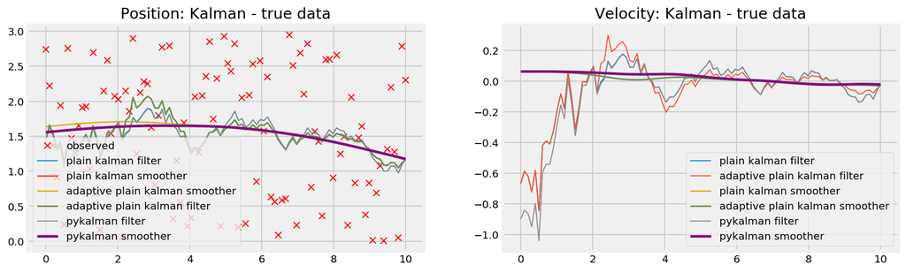

```python
fig = plt.figure(figsize=plt.figaspect(0.3))

ax = fig.add_subplot(1, 2, 1)
ax.plot(t, np.array(y).ravel() - true_x, 'rx', linewidth=1.0, label="observed")
ax.plot(t, np.array(means[:, 0]).ravel() - true_x, linewidth=1.0, label="plain kalman filter")
ax.plot(t, np.array(smeans[:, 0]).ravel() - true_x, linewidth=1.5, label="plain kalman smoother")
ax.plot(t, np.array(adsmeans[:, 0]).ravel() - true_x, linewidth=1.5, label="adaptive plain kalman smoother")
ax.plot(t, np.array(admeans[:, 0]).ravel() - true_x, linewidth=1.5, label="adaptive plain kalman filter")
ax.plot(t, filtered_state_means[:, 0] - true_x, linewidth=1.0, label="pykalman filter")
# ax.plot(t, filtered_state_means_em[:, 0] - true_x, 'g-', linewidth=1.0, label="pykalman_em filter")
ax.plot(t, smoothed_state_means[:, 0] - true_x, linewidth=2.5, label="pykalman smoother")
# ax.plot(t, smoothed_state_means_em[:, 0] - true_x, 'c-.', linewidth=0.5, label="pykalman_em smoother")
ax.legend(loc="best")
ax.set_title("Position: Kalman - true data")

ax2 = fig.add_subplot(1, 2, 2)
ax2.plot(t, np.array(means[:, 1]).ravel() - true_v, linewidth=1.0, label="plain kalman filter")
ax2.plot(t, np.array(admeans[:, 1]).ravel() - true_v, linewidth=1.0, label="adaptive plain kalman filter")
ax2.plot(t, np.array(smeans[:, 1]).ravel() - true_v, linewidth=1.5, label="plain kalman smoother")
ax2.plot(t, np.array(adsmeans[:, 1]).ravel() - true_v, linewidth=1.5, label="adaptive plain kalman smoother")
ax2.plot(t, filtered_state_means[:, 1] - true_v, linewidth=1.0, label="pykalman filter")
# ax2.plot(t, filtered_state_means_em[:, 1] - true_v, 'g-', linewidth=1.0, label="pykalman_em filter")
ax2.plot(t, smoothed_state_means[:, 1] - true_v, linewidth=2.5, label="pykalman smoother")
# ax2.plot(t, smoothed_state_means_em[:, 1] - true_v, 'c-.', linewidth=0.5, label="pykalman_em smoother")
ax2.legend(loc="best")
ax2.set_title("Velocity: Kalman - true data")

plt.show()
```

### Sequential Update on Unobserved Data

We will do forecasting, to find the next observation by continuously updating Kalman filter parameters on a given window.

```python
window = 30
pos = []
vel = []

pkf = PlainKalmanFilter(x_0, Sigma_0, A, G, Q, R, B, u)
print(pkf)

for i in range(window, N):
    obs = y.T[:i]#[-window:]
    next_mean, next_cov, _, _ = pkf.forecast(obs.T, 1)
    pos.append(next_mean[:,0])
    vel.append(next_mean[:,1])

pos = np.array(pos)[:,0,0]
vel = np.array(vel)[:,0,0]
```

```
PlainKalmanFilter(x[(2, 1)], Sigma[(2, 2)], A[(2, 2)], G[(1, 2)], Q[(2, 2)], R[(1, 1)], B[(2, 1)], u[(1, 1)])
```

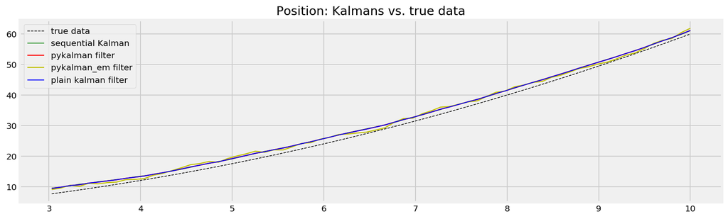

```python
fig = plt.figure(figsize=plt.figaspect(0.3))

ax = fig.add_subplot(1, 1, 1)
ax.plot(t[window:], true_x[window:], 'k--', linewidth=0.8, label="true data")
ax.plot(t[window:], pos, 'g-', linewidth=0.8, label="sequential Kalman")
ax.plot(t[window:], filtered_state_means[window:,0], 'r-', linewidth=1.2, label="pykalman filter")
ax.plot(t[window:], filtered_state_means_em[window:,0], 'y-', linewidth=1.2, label="pykalman_em filter")
ax.plot(t[window:], np.array(means[:,0]).ravel()[window:], 'b-', linewidth=1.0, label="plain kalman filter")

ax.legend(loc="upper left")
ax.set_title("Position: Kalmans vs. true data")
plt.show()
```

Comparisons essentially show that there is no significant difference between discussed filters (same for smoothers).

# Projectile Motion in 2D

### Observing $(x_1, x_2)$

Our state will be: $x_t = (x_1, \dot{x}_1, \ddot{x}_1, x_2, \dot{x}_2, \ddot{x}_2)^T$, the transition, transition covariance and observation matrices will be:

$$ A = \begin{bmatrix} 1 & dt & dt^2/2 & 0 & 0 & 0 \\ 0 & 1 & dt & 0 & 0 & 0 \\ 0 & 0 & 1 & 0 & 0 & 0 \\ 0 & 0 & 0 & 1 & dt & dt^2/2\\ 0 & 0 & 0 & 0 & 1 & dt \\ 0 & 0 & 0 & 0 & 0 & 1 \end{bmatrix} , $$$$ Q = \begin{bmatrix} \frac{1}{4}dt^4 & \frac{1}{2}dt^3 & \frac{1}{2}dt^2 & 0 & 0 & 0 \\ \frac{1}{2}dt^3 & dt^2 & dt & 0 & 0 & 0 \\ \frac{1}{2}dt^2 & dt & 1 & 0 & 0 & 0 \\ 0 & 0 & 0 & \frac{1}{4}dt^4 & \frac{1}{2}dt^3 & \frac{1}{2}dt^2 \\ 0 & 0 & 0 & \frac{1}{2}dt^3 & dt^2 & dt \\ 0 & 0 & 0 & \frac{1}{2}dt^2 & dt & 1 \\ \end{bmatrix} \sigma^2_a, $$

$$ G = \begin{bmatrix} 1 & 0 & 0 & 0 & 0 & 0\\ 0 & 0 & 0 & 1 & 0 & 0 \end{bmatrix}. $$

```python
sigma_a = 0.9
sigma_x = 3.5

# transition matrix
A = np.array([[1, dt,  0.5 * dt ** 2, 0, 0,  0],
              [0,  1,  dt,            0, 0,  0],
              [0,  0,  1,             0, 0,  0],
              [0,  0,  0,             1, dt, 0.5 * dt ** 2],
              [0,  0,  0,             0, 1,  dt],
              [0,  0,  0,             0, 0,  1]])

# transition covariance matrix
Q = np.array([[0.25 * dt ** 4, 0.5 * dt ** 3, 0.5 * dt ** 2, 0, 0, 0],
              [0.5 * dt ** 3,  dt ** 2,       dt,            0, 0, 0],
              [0.5 * dt ** 2,  dt,            1,             0, 0, 0],
              [0, 0, 0, 0.25 * dt ** 4, 0.5 * dt ** 3, 0.5 * dt ** 2],
              [0, 0, 0, 0.5 * dt ** 3,  dt ** 2,       dt],
              [0, 0, 0, 0.5 * dt ** 2,  dt,            1]]) * sigma_a ** 2

G = np.array([[1, 0, 0, 0, 0, 0],
              [0, 0, 0, 1, 0, 0]])

R = np.array([[1, 0],
              [0, 1]]) * sigma_x ** 2

B = None
u = None

x_0 = np.array([0.1, 0.1, 0.1, 0, 0, 8]).reshape(6, 1)
Sigma_0 = (sigma_x ** 2) * np.eye(6)
```

## Generating Noisy Data

```python
n_iter = 10
dt = 0.1
t_max = 10
N = int(t_max/dt)

x10, x20 = 0.0, 0.0
v10, v20 = 0.0, 0.0
a1, a2 = 1.0, 10.0

t = np.linspace(0.0, t_max, N)
true_x1 = x10 + v10 * t + 0.5 * a1 * t ** 2
true_x2 = x20 + v20 * t + 0.5 * a2 * t ** 2

true_v1 = v10 + a1 * t
true_v2 = v20 + a2 * t

true = [true_x1, true_v1, a1*np.ones(N), true_x2, true_v2, a2*np.ones(N)]

observed_x1 = true_x1 + sigma_x * np.random.random(N) #+ np.random.poisson(2.0, N)
observed_x2 = true_x2 + sigma_x * np.random.random(N) #+ np.random.poisson(2.0, N)

y = np.vstack((observed_x1, observed_x2)).reshape(2, N)
```

## Kalman Filtering/Smoothing/Forecasting

```python
pkf = PlainKalmanFilter(x_0, Sigma_0, A, G, Q, R, B, u)
print(pkf)

xc, Sigmac = x_0, Sigma_0
means, covs = pkf.filter(y)

#############################################################################

smeans, scovs = pkf.smooth(y)

#############################################################################

n_steps = 50
fsmeans, fscovs, fomean, focovs = pkf.forecast(y, n_steps)

#############################################################################

akf = AdaptiveKalman(x_0, Sigma_0, A, G, Q, R, B, u, window=20)
admeans, adcovs = akf.filter(y)
adsmeans, adscovs = akf.smooth(y)
adfsmeans, adfscovs, adfomean, adfocovs = akf.forecast(y, n_steps)
```

```
PlainKalmanFilter(x[(6, 1)], Sigma[(6, 6)], A[(6, 6)], G[(2, 6)], Q[(6, 6)], R[(2, 2)])
```

## $x_1$ and $v_1$ vs time

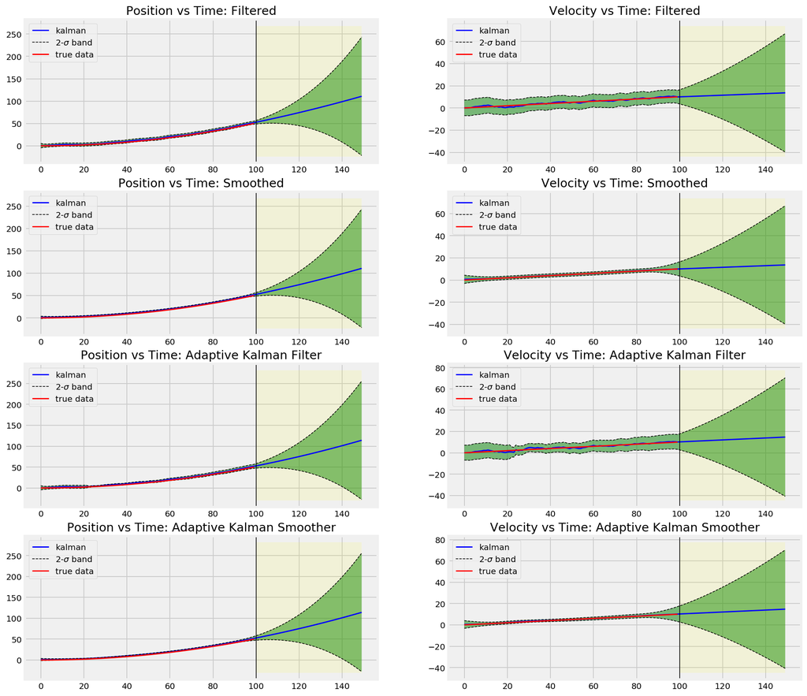

```python
fig = plt.figure(figsize=(15,30))

j = 0
j1 = 1
ax1 = fig.add_subplot(8, 2, 1)
plot_kalman(means[:, j, :], covs[:, j, j], fsmeans[:, j, :], fscovs[:, j, j], true[j], num_sigmas=2,
            ax=ax1, title="Position vs Time: Filtered")

ax2 = fig.add_subplot(8, 2, 2)
plot_kalman(means[:, j1, :], covs[:, j1, j1], fsmeans[:, j1, :], fscovs[:, j1, j1], true[j1], num_sigmas=2,
            ax=ax2, title="Velocity vs Time: Filtered")

ax3 = fig.add_subplot(8, 2, 3)
plot_kalman(smeans[:, j, :], scovs[:, j, j], fsmeans[:, j, :], fscovs[:, j, j], true[j], num_sigmas=2,
            ax=ax3, title="Position vs Time: Smoothed")

ax4 = fig.add_subplot(8, 2, 4)
plot_kalman(smeans[:, j1, :], scovs[:, j1, j1], fsmeans[:, j1, :], fscovs[:, j1, j1], true[j1], num_sigmas=2,
            ax=ax4, title="Velocity vs Time: Smoothed")

ax5 = fig.add_subplot(8, 2, 5)
plot_kalman(admeans[:, j, :], adcovs[:, j, j], adfsmeans[:, j, :], adfscovs[:, j, j], true[j], num_sigmas=2,
            ax=ax5, title="Position vs Time: Adaptive Kalman Filter")

ax6 = fig.add_subplot(8, 2, 6)
plot_kalman(admeans[:, j1, :], adcovs[:, j1, j1], adfsmeans[:, j1, :], adfscovs[:, j1, j1], true[j1], num_sigmas=2,
            ax=ax6, title="Velocity vs Time: Adaptive Kalman Filter")

ax7 = fig.add_subplot(8, 2, 7)
plot_kalman(adsmeans[:, j, :], adscovs[:, j, j], adfsmeans[:, j, :], adfscovs[:, j, j], true[j], num_sigmas=2,
            ax=ax7, title="Position vs Time: Adaptive Kalman Smoother")

ax8 = fig.add_subplot(8, 2, 8)
plot_kalman(adsmeans[:, j1, :], adscovs[:, j1, j1], adfsmeans[:, j1, :], adfscovs[:, j1, j1], true[j1], num_sigmas=2,
            ax=ax8, title="Velocity vs Time: Adaptive Kalman Smoother")

plt.show()
```

## $x_2$ and $v_2$ vs time

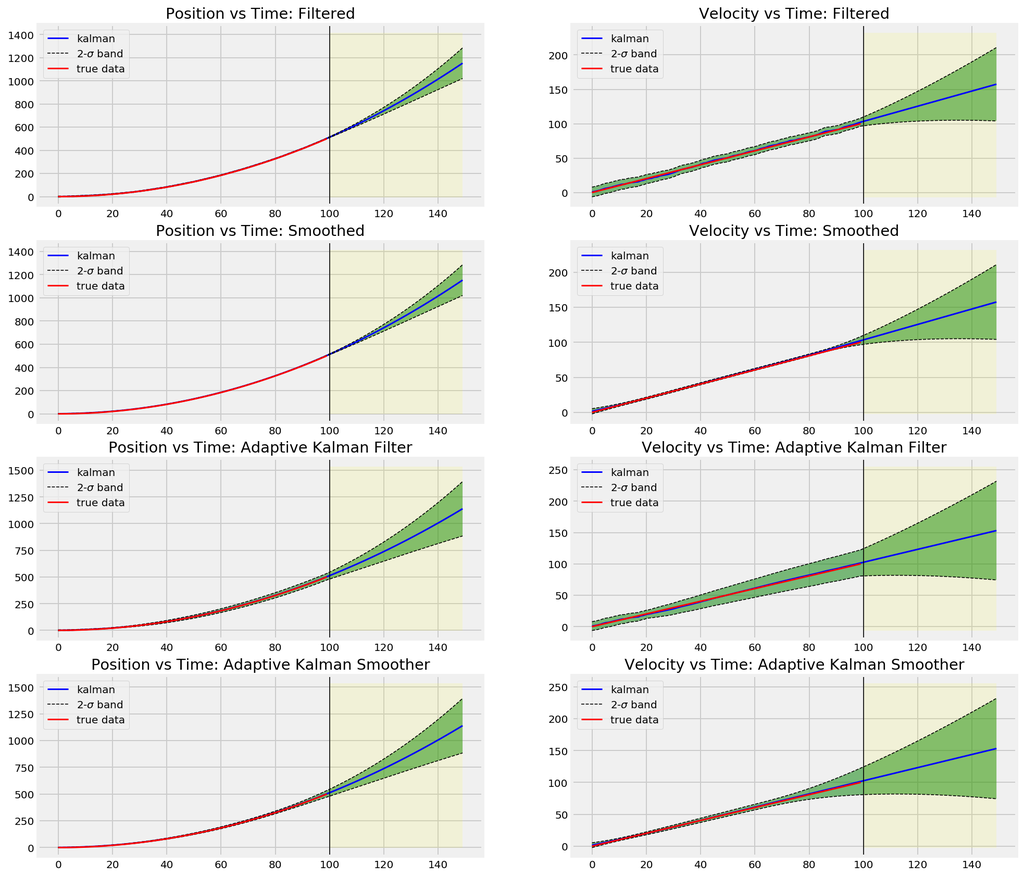

```python
fig = plt.figure(figsize=(15,30))

j = 3
j1 = 4
ax1 = fig.add_subplot(8, 2, 1)
plot_kalman(means[:, j, :], covs[:, j, j], fsmeans[:, j, :], fscovs[:, j, j], true[j], num_sigmas=2,
            ax=ax1, title="Position vs Time: Filtered")

ax2 = fig.add_subplot(8, 2, 2)
plot_kalman(means[:, j1, :], covs[:, j1, j1], fsmeans[:, j1, :], fscovs[:, j1, j1], true[j1], num_sigmas=2,
            ax=ax2, title="Velocity vs Time: Filtered")

ax3 = fig.add_subplot(8, 2, 3)
plot_kalman(smeans[:, j, :], scovs[:, j, j], fsmeans[:, j, :], fscovs[:, j, j], true[j], num_sigmas=2,
            ax=ax3, title="Position vs Time: Smoothed")

ax4 = fig.add_subplot(8, 2, 4)
plot_kalman(smeans[:, j1, :], scovs[:, j1, j1], fsmeans[:, j1, :], fscovs[:, j1, j1], true[j1], num_sigmas=2,
            ax=ax4, title="Velocity vs Time: Smoothed")

ax5 = fig.add_subplot(8, 2, 5)
plot_kalman(admeans[:, j, :], adcovs[:, j, j], adfsmeans[:, j, :], adfscovs[:, j, j], true[j], num_sigmas=2,
            ax=ax5, title="Position vs Time: Adaptive Kalman Filter")

ax6 = fig.add_subplot(8, 2, 6)
plot_kalman(admeans[:, j1, :], adcovs[:, j1, j1], adfsmeans[:, j1, :], adfscovs[:, j1, j1], true[j1], num_sigmas=2,
            ax=ax6, title="Velocity vs Time: Adaptive Kalman Filter")

ax7 = fig.add_subplot(8, 2, 7)
plot_kalman(adsmeans[:, j, :], adscovs[:, j, j], adfsmeans[:, j, :], adfscovs[:, j, j], true[j], num_sigmas=2,
            ax=ax7, title="Position vs Time: Adaptive Kalman Smoother")

ax8 = fig.add_subplot(8, 2, 8)
plot_kalman(adsmeans[:, j1, :], adscovs[:, j1, j1], adfsmeans[:, j1, :], adfscovs[:, j1, j1], true[j1], num_sigmas=2,
            ax=ax8, title="Velocity vs Time: Adaptive Kalman Smoother")

plt.show()
```

## $a_1$ and $a_2$ vs time

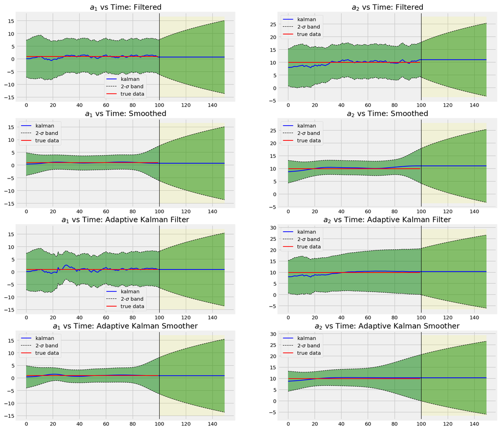

```python
fig = plt.figure(figsize=(15,30))

j = 2
j1 = 5
ax1 = fig.add_subplot(8, 2, 1)
plot_kalman(means[:, j, :], covs[:, j, j], fsmeans[:, j, :], fscovs[:, j, j], true[j], num_sigmas=2,
            ax=ax1, title="$a_1$ vs Time: Filtered")

ax2 = fig.add_subplot(8, 2, 2)
plot_kalman(means[:, j1, :], covs[:, j1, j1], fsmeans[:, j1, :], fscovs[:, j1, j1], true[j1], num_sigmas=2,
            ax=ax2, title="$a_2$ vs Time: Filtered")

ax3 = fig.add_subplot(8, 2, 3)
plot_kalman(smeans[:, j, :], scovs[:, j, j], fsmeans[:, j, :], fscovs[:, j, j], true[j], num_sigmas=2,
            ax=ax3, title="$a_1$ vs Time: Smoothed")

ax4 = fig.add_subplot(8, 2, 4)
plot_kalman(smeans[:, j1, :], scovs[:, j1, j1], fsmeans[:, j1, :], fscovs[:, j1, j1], true[j1], num_sigmas=2,
            ax=ax4, title="$a_2$ vs Time: Smoothed")

ax5 = fig.add_subplot(8, 2, 5)
plot_kalman(admeans[:, j, :], adcovs[:, j, j], adfsmeans[:, j, :], adfscovs[:, j, j], true[j], num_sigmas=2,
            ax=ax5, title="$a_1$ vs Time: Adaptive Kalman Filter")

ax6 = fig.add_subplot(8, 2, 6)
plot_kalman(admeans[:, j1, :], adcovs[:, j1, j1], adfsmeans[:, j1, :], adfscovs[:, j1, j1], true[j1], num_sigmas=2,
            ax=ax6, title="$a_2$ vs Time: Adaptive Kalman Filter")

ax7 = fig.add_subplot(8, 2, 7)
plot_kalman(adsmeans[:, j, :], adscovs[:, j, j], adfsmeans[:, j, :], adfscovs[:, j, j], true[j], num_sigmas=2,
            ax=ax7, title="$a_1$ vs Time: Adaptive Kalman Smoother")

ax8 = fig.add_subplot(8, 2, 8)
plot_kalman(adsmeans[:, j1, :], adscovs[:, j1, j1], adfsmeans[:, j1, :], adfscovs[:, j1, j1], true[j1], num_sigmas=2,
            ax=ax8, title="$a_2$ vs Time: Adaptive Kalman Smoother")

plt.show()
```

## Appendix: Comparisons

```python
kf = KalmanFilter(initial_state_mean=x_0.T.tolist()[0],
                  initial_state_covariance=Sigma_0,
                  transition_matrices=A,
                  transition_covariance=Q,
                  observation_matrices=G,
                  observation_covariance=R)

# kf = KalmanFilter(transition_matrices=A, observation_matrices=G)
# kf = kf.em(measurements, n_iter=n_iter)

(filtered_state_means, filtered_state_covariances) = kf.filter(y.T.tolist())
(smoothed_state_means, smoothed_state_covariances) = kf.smooth(y.T.tolist())
```

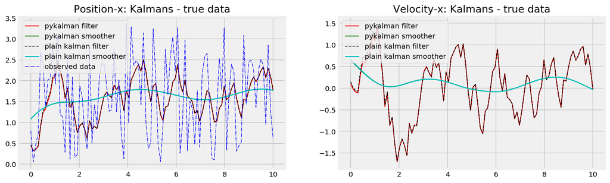

```python
fig = plt.figure(figsize=plt.figaspect(0.3))

ax = fig.add_subplot(1, 2, 1)

ax.plot(t, filtered_state_means[:,0]-true_x1, 'r-', linewidth=1.2, label="pykalman filter")
ax.plot(t, smoothed_state_means[:,0]-true_x1, 'g-', linewidth=1.2, label="pykalman smoother")
ax.plot(t, np.array(means[:, 0]).ravel() - true_x1, 'k--', linewidth=1.0, label="plain kalman filter")
ax.plot(t, np.array(smeans[:, 0]).ravel() - true_x1, 'c-', linewidth=1.5, label="plain kalman smoother")

#ax.plot(t, true_x1, 'k--', linewidth=0.8, label="true data")
ax.plot(t, observed_x1-true_x1, 'b-.', linewidth=0.8, label="observed data")
ax.legend(loc="upper left")
ax.set_title("Position-x: Kalmans - true data")

ax2 = fig.add_subplot(1, 2, 2)
ax2.plot(t, filtered_state_means[:,1]-true_v1, 'r-', linewidth=1.2, label="pykalman filter")
ax2.plot(t, smoothed_state_means[:,1]-true_v1, 'g-', linewidth=1.2, label="pykalman smoother")
ax2.plot(t, np.array(means[:, 1]).ravel() - true_v1, 'k--', linewidth=1.0, label="plain kalman filter")
ax2.plot(t, np.array(smeans[:, 1]).ravel() - true_v1, 'c-', linewidth=1.5, label="plain kalman smoother")

ax2.legend(loc="upper left")
ax2.set_title("Velocity-x: Kalmans - true data")

plt.show()
```

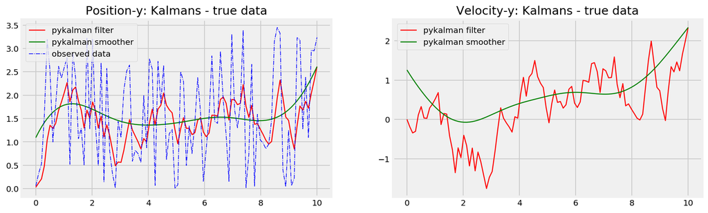

```python
fig = plt.figure(figsize=plt.figaspect(0.3))

ax = fig.add_subplot(1, 2, 1)
ax.plot(t, filtered_state_means[:,3]-true_x2, 'r-', linewidth=1.2, label="pykalman filter")
ax.plot(t, smoothed_state_means[:,3]-true_x2, 'g-', linewidth=1.2, label="pykalman smoother")
ax.plot(t, observed_x2-true_x2, 'b-.', linewidth=0.8, label="observed data")
ax.legend(loc="upper left")
ax.set_title("Position-y: Kalmans - true data")

ax2 = fig.add_subplot(1, 2, 2)
ax2.plot(t, filtered_state_means[:,4]-true_v2, 'r-', linewidth=1.2, label="pykalman filter")
ax2.plot(t, smoothed_state_means[:,4]-true_v2, 'g-', linewidth=1.2, label="pykalman smoother")
ax2.legend(loc="upper left")
ax2.set_title("Velocity-y: Kalmans - true data")

plt.show()
```

```python
error1 = [(means[:,i,0] - true[i]).std() for i in range(6)]
error2 = [(smeans[:,i,0] - true[i]).std() for i in range(6)]
error3 = [(admeans[:,i,0] - true[i]).std() for i in range(6)]
error4 = [(adsmeans[:,i,0] - true[i]).std() for i in range(6)]
error5 = [(filtered_state_means[:,i] - true[i]).std() for i in range(6)]
error6 = [(smoothed_state_means[:,i] - true[i]).std() for i in range(6)]

[sum(e) for e in [error1, error2, error3, error4, error5, error6]]
```

```
[3.999742845822939,
 1.9002455826158444,
 4.5836242656825545,
 2.0357380693968827,
 3.8560717687748234,
 1.8131181413212145]
```

# Kalman Filter for Asynchronous Measurements

Assumption of update rates:

- 1.Accelerometer collects data (from IMU) at 10 Hz
- 2.GPS collects data (lon/lat/alt) with at 1 Hz

We will measure $(x_1, x_2, a_1, a_2)$

```python
dt = 0.1
sigma_x = 10.0
sigma_a = 1.0

# transition matrix
A = np.matrix([[1, dt,  0.5 * dt ** 2, 0, 0,  0],
               [0,  1,  dt,            0, 0,  0],
               [0,  0,  1,             0, 0,  0],
               [0,  0,  0,             1, dt, 0.5 * dt ** 2],
               [0,  0,  0,             0, 1,  dt],
               [0,  0,  0,             0, 0,  1]])

# transition covariance matrix
Q = np.matrix([[0.25 * dt ** 4, 0.5 * dt ** 3, 0.5 * dt ** 2, 0, 0, 0],
               [0.5 * dt ** 3,  dt ** 2,       dt,            0, 0, 0],
               [0.5 * dt ** 2,  dt,            1,             0, 0, 0],
               [0, 0, 0, 0.25 * dt ** 4, 0.5 * dt ** 3, 0.5 * dt ** 2],
               [0, 0, 0, 0.5 * dt ** 3,  dt ** 2,       dt],
               [0, 0, 0, 0.5 * dt ** 2,  dt,            1]]) * sigma_a ** 2

G = np.matrix([[1, 0, 0, 0, 0, 0],
               [0, 0, 0, 1, 0, 0],
               [0, 0, 1, 0, 0, 0],
               [0, 0, 0, 0, 0, 1]])


R = np.matrix([[sigma_x**2, 0.0, 0.0, 0.0],
               [0.0, sigma_x**2, 0.0, 0.0],
               [0.0, 0.0, sigma_a**2, 0.0],
               [0.0, 0.0, 0.0, sigma_a**2]])

B = None
u = None

x_0 = np.matrix([0.0, 1.0, 0.1, 0.0, 0.0, -1.0]).T
Sigma_0 = np.eye(6) * sigma_x ** 2
```

## Generating Noisy Data

```python
t_max = 10
N = int(t_max/dt)

x10 = 0
x20 = 0
v10 = 10.5
v20 = 1.5
a1 = 1.1
a2 = -1.1

t = np.linspace(0.0, t_max, N)

true_x1 = x10 + v10 * t + 0.5 * a1 * t ** 2
true_x2 = x20 + v20 * t + 0.5 * a2 * t ** 2
true_v1 = v10 + a1 * t
true_v2 = v20 + a2 * t

obs_x1 = true_x1 + sigma_x * np.random.randn(N)
obs_x2 = true_x2 + sigma_x * np.random.randn(N)
obs_a1 = a1 + sigma_a * np.random.randn(N)
obs_a2 = a2 + sigma_a * np.random.randn(N)

true = [true_x1, true_v1, a1*np.ones(N), true_x2, true_v2, a2*np.ones(N)]

# Generate GPS vector t-th entry of which is true if there is GPS data at time t, and false othewise
GPS = np.ndarray(N, dtype='bool')
GPS[0] = True

# Less new position updates
for i in range(1, N):
    if i % 10 == 0:
        GPS[i]=True
    else:
        obs_x1[i] = obs_x1[i-1]
        obs_x2[i] = obs_x2[i-1]
        GPS[i]=False

y = np.vstack((obs_x1, obs_x2, obs_a1, obs_a2))
```

## Plot of Observations

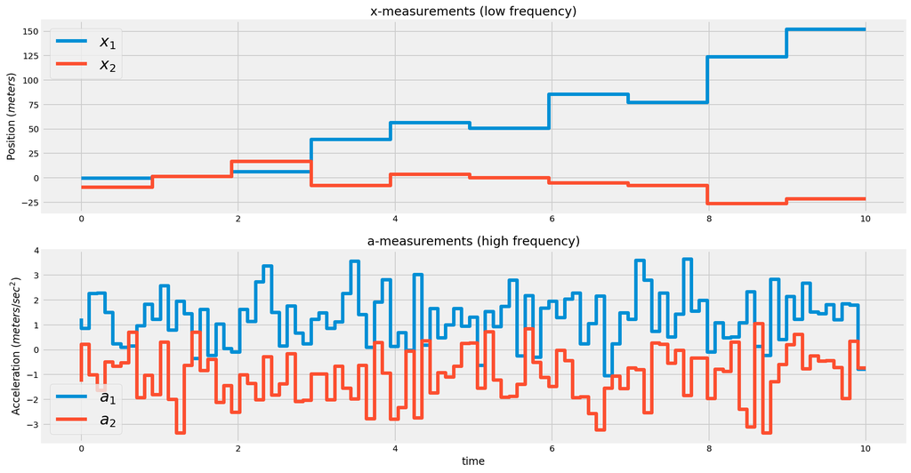

```python
fig = plt.figure(figsize=(16,9))
plt.subplot(211)
plt.step(t, obs_x1, label='$x_1$')
plt.step(t, obs_x2, label='$x_2$')
plt.ylabel(r'Position $(meters)$')
plt.title('x-measurements (low frequency)')
#plt.ylim([-10, 10])
plt.legend(loc='best',prop={'size':18})

plt.subplot(212)
plt.step(t, obs_a1, label='$a_1$')
plt.step(t, obs_a2, label='$a_2$')
plt.ylabel(r'Acceleration $(meters/sec^2)$')
plt.xlabel('time')
#plt.ylim([-1, 1])
plt.title('a-measurements (high frequency)')
plt.legend(loc='best',prop={'size':18})
plt.show()
```

## Direct Application of Kalman Filter on Asynchronous Data

```python
pkf = PlainKalmanFilter(x_0, Sigma_0, A, G, Q, R, B, u)
print(pkf)

xc, Sigmac = x_0, Sigma_0
means, covs = pkf.filter(y)

#############################################################################

smeans, scovs = pkf.smooth(y)

#############################################################################

n_steps = 15
fsmeans, fscovs, fomean, focovs = pkf.forecast(y, n_steps)

#############################################################################

akf = AdaptiveKalman(x_0, Sigma_0, A, G, Q, R, B, u, window=20)
admeans, adcovs = akf.filter(y)
adsmeans, adscovs = akf.smooth(y)
adfsmeans, adfscovs, adfomean, adfocovs = akf.forecast(y, n_steps)
```

```
PlainKalmanFilter(x[(6, 1)], Sigma[(6, 6)], A[(6, 6)], G[(4, 6)], Q[(6, 6)], R[(4, 4)])
```

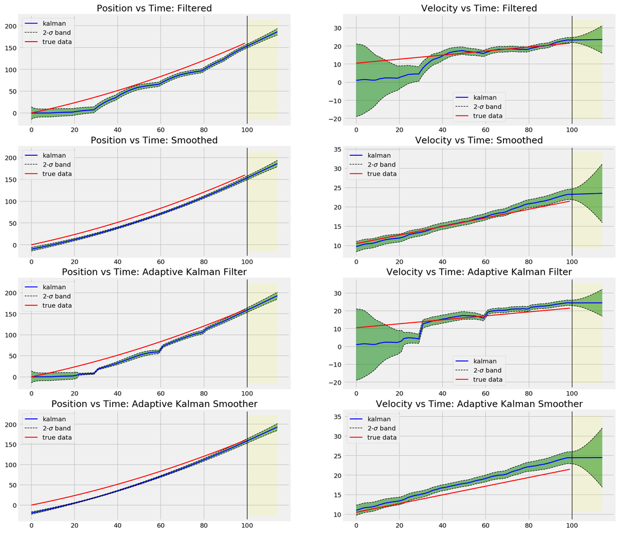

```python
fig = plt.figure(figsize=(15,30))

j = 0
j1 = 1
ax1 = fig.add_subplot(8, 2, 1)
plot_kalman(means[:, j, :], covs[:, j, j], fsmeans[:, j, :], fscovs[:, j, j], true[j], num_sigmas=2,
            ax=ax1, title="Position vs Time: Filtered")

ax2 = fig.add_subplot(8, 2, 2)
plot_kalman(means[:, j1, :], covs[:, j1, j1], fsmeans[:, j1, :], fscovs[:, j1, j1], true[j1], num_sigmas=2,
            ax=ax2, title="Velocity vs Time: Filtered")

ax3 = fig.add_subplot(8, 2, 3)
plot_kalman(smeans[:, j, :], scovs[:, j, j], fsmeans[:, j, :], fscovs[:, j, j], true[j], num_sigmas=2,
            ax=ax3, title="Position vs Time: Smoothed")

ax4 = fig.add_subplot(8, 2, 4)
plot_kalman(smeans[:, j1, :], scovs[:, j1, j1], fsmeans[:, j1, :], fscovs[:, j1, j1], true[j1], num_sigmas=2,
            ax=ax4, title="Velocity vs Time: Smoothed")

ax5 = fig.add_subplot(8, 2, 5)
plot_kalman(admeans[:, j, :], adcovs[:, j, j], adfsmeans[:, j, :], adfscovs[:, j, j], true[j], num_sigmas=2,
            ax=ax5, title="Position vs Time: Adaptive Kalman Filter")

ax6 = fig.add_subplot(8, 2, 6)
plot_kalman(admeans[:, j1, :], adcovs[:, j1, j1], adfsmeans[:, j1, :], adfscovs[:, j1, j1], true[j1], num_sigmas=2,
            ax=ax6, title="Velocity vs Time: Adaptive Kalman Filter")

ax7 = fig.add_subplot(8, 2, 7)
plot_kalman(adsmeans[:, j, :], adscovs[:, j, j], adfsmeans[:, j, :], adfscovs[:, j, j], true[j], num_sigmas=2,
            ax=ax7, title="Position vs Time: Adaptive Kalman Smoother")

ax8 = fig.add_subplot(8, 2, 8)
plot_kalman(adsmeans[:, j1, :], adscovs[:, j1, j1], adfsmeans[:, j1, :], adfscovs[:, j1, j1], true[j1], num_sigmas=2,
            ax=ax8, title="Velocity vs Time: Adaptive Kalman Smoother")

plt.show()
```

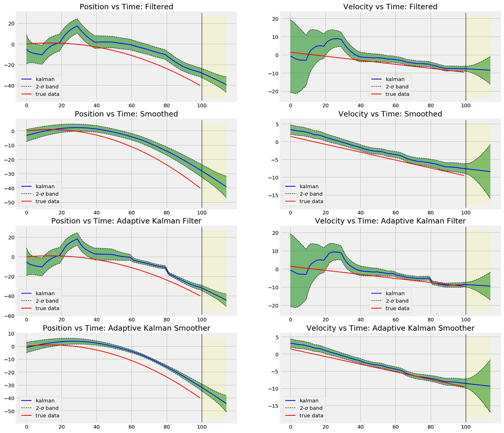

```python
fig = plt.figure(figsize=(15,30))

j = 3
j1 = 4
ax1 = fig.add_subplot(8, 2, 1)
plot_kalman(means[:, j, :], covs[:, j, j], fsmeans[:, j, :], fscovs[:, j, j], true[j], num_sigmas=2,
            ax=ax1, title="Position vs Time: Filtered")

ax2 = fig.add_subplot(8, 2, 2)
plot_kalman(means[:, j1, :], covs[:, j1, j1], fsmeans[:, j1, :], fscovs[:, j1, j1], true[j1], num_sigmas=2,
            ax=ax2, title="Velocity vs Time: Filtered")

ax3 = fig.add_subplot(8, 2, 3)
plot_kalman(smeans[:, j, :], scovs[:, j, j], fsmeans[:, j, :], fscovs[:, j, j], true[j], num_sigmas=2,
            ax=ax3, title="Position vs Time: Smoothed")

ax4 = fig.add_subplot(8, 2, 4)
plot_kalman(smeans[:, j1, :], scovs[:, j1, j1], fsmeans[:, j1, :], fscovs[:, j1, j1], true[j1], num_sigmas=2,
            ax=ax4, title="Velocity vs Time: Smoothed")

ax5 = fig.add_subplot(8, 2, 5)
plot_kalman(admeans[:, j, :], adcovs[:, j, j], adfsmeans[:, j, :], adfscovs[:, j, j], true[j], num_sigmas=2,
            ax=ax5, title="Position vs Time: Adaptive Kalman Filter")

ax6 = fig.add_subplot(8, 2, 6)
plot_kalman(admeans[:, j1, :], adcovs[:, j1, j1], adfsmeans[:, j1, :], adfscovs[:, j1, j1], true[j1], num_sigmas=2,
            ax=ax6, title="Velocity vs Time: Adaptive Kalman Filter")

ax7 = fig.add_subplot(8, 2, 7)
plot_kalman(adsmeans[:, j, :], adscovs[:, j, j], adfsmeans[:, j, :], adfscovs[:, j, j], true[j], num_sigmas=2,
            ax=ax7, title="Position vs Time: Adaptive Kalman Smoother")

ax8 = fig.add_subplot(8, 2, 8)
plot_kalman(adsmeans[:, j1, :], adscovs[:, j1, j1], adfsmeans[:, j1, :], adfscovs[:, j1, j1], true[j1], num_sigmas=2,
            ax=ax8, title="Velocity vs Time: Adaptive Kalman Smoother")

plt.show()
```

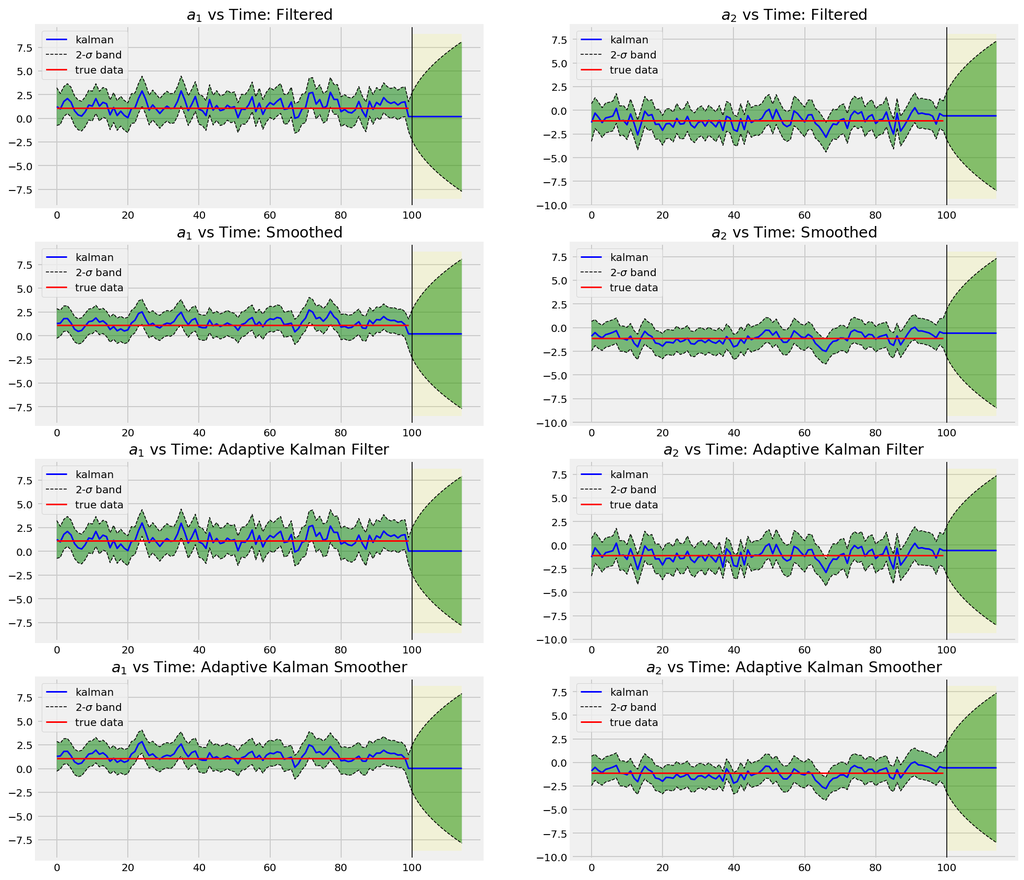

```python
fig = plt.figure(figsize=(15,30))

j = 2
j1 = 5
ax1 = fig.add_subplot(8, 2, 1)
plot_kalman(means[:, j, :], covs[:, j, j], fsmeans[:, j, :], fscovs[:, j, j], true[j], num_sigmas=2,
            ax=ax1, title="$a_1$ vs Time: Filtered")

ax2 = fig.add_subplot(8, 2, 2)
plot_kalman(means[:, j1, :], covs[:, j1, j1], fsmeans[:, j1, :], fscovs[:, j1, j1], true[j1], num_sigmas=2,
            ax=ax2, title="$a_2$ vs Time: Filtered")

ax3 = fig.add_subplot(8, 2, 3)
plot_kalman(smeans[:, j, :], scovs[:, j, j], fsmeans[:, j, :], fscovs[:, j, j], true[j], num_sigmas=2,
            ax=ax3, title="$a_1$ vs Time: Smoothed")

ax4 = fig.add_subplot(8, 2, 4)
plot_kalman(smeans[:, j1, :], scovs[:, j1, j1], fsmeans[:, j1, :], fscovs[:, j1, j1], true[j1], num_sigmas=2,
            ax=ax4, title="$a_2$ vs Time: Smoothed")

ax5 = fig.add_subplot(8, 2, 5)
plot_kalman(admeans[:, j, :], adcovs[:, j, j], adfsmeans[:, j, :], adfscovs[:, j, j], true[j], num_sigmas=2,
            ax=ax5, title="$a_1$ vs Time: Adaptive Kalman Filter")

ax6 = fig.add_subplot(8, 2, 6)
plot_kalman(admeans[:, j1, :], adcovs[:, j1, j1], adfsmeans[:, j1, :], adfscovs[:, j1, j1], true[j1], num_sigmas=2,
            ax=ax6, title="$a_2$ vs Time: Adaptive Kalman Filter")

ax7 = fig.add_subplot(8, 2, 7)
plot_kalman(adsmeans[:, j, :], adscovs[:, j, j], adfsmeans[:, j, :], adfscovs[:, j, j], true[j], num_sigmas=2,
            ax=ax7, title="$a_1$ vs Time: Adaptive Kalman Smoother")

ax8 = fig.add_subplot(8, 2, 8)
plot_kalman(adsmeans[:, j1, :], adscovs[:, j1, j1], adfsmeans[:, j1, :], adfscovs[:, j1, j1], true[j1], num_sigmas=2,
            ax=ax8, title="$a_2$ vs Time: Adaptive Kalman Smoother")

plt.show()
```

## Kalman Filtering on Asynchronous Data

```python
class AsyncKalman(PlainKalmanFilter):
    """Simple Asynchronous Kalman filter that allows to treat cases
       when observables arrive asynchronously."""
    def __init__(self, x, Sigma, A, G, Q, R, GPS, B=None, u=None):
        super().__init__(x, Sigma, A, G, Q, R, B, u)
        self.GPS = GPS

    def filter(self, y):
        """ Performs sequential state update followed by measurement update
        if GPS signal/data is available.
        GPS is a boolean array of same length as y.
        Returns all {x_t}, {Sigma_t} given data {y_t}."""
        assert (y.shape[0] == self.n_obs)
        assert (y.shape[1] == self.GPS.shape[0])
        means = []
        covs = []
        xp, Sigmap = self.x, self.Sigma
        for i, yi in enumerate(y.T):
            obs = np.atleast_2d(yi).reshape(self.n_obs, 1)
            xp, Sigmap = self.predict_next_state(xp, Sigmap)
            if self.GPS[i]:
                xp, Sigmap = self.filter_state(obs, xp, Sigmap)
            means.append(xp)
            covs.append(Sigmap)
        return np.array(means), np.array(covs)


class AsyncAdaptiveKalman(AsyncKalman):
    """Simple Adaptive Kalman adjusted to Asynchronous Kalman filter. """
    def __init__(self, x, Sigma, A, G, Q, R, GPS, B=None, u=None, window=10):
        super().__init__(x, Sigma, A, G, Q, R, GPS, B, u)
        self.window = window
        self.Rold = self.R.copy()

    def filter(self, y):
        """ Performs sequential state update followed by measurement update.
        Updates [R], on a rolling [window] interval.
        Returns all {x_t}, {Sigma_t} given data {y_t}."""
        assert (y.shape[0] == self.n_obs)
        assert (y.shape[1] > self.window)
        means = []
        covs = []
        xp, Sigmap = self.x, self.Sigma
        for i, yi in enumerate(y.T):
            obs = np.atleast_2d(yi).reshape(self.n_obs, 1)
            xp, Sigmap = self.predict_next_state(xp, Sigmap)
            if self.GPS[i]:
                xp, Sigmap = self.filter_state(obs, xp, Sigmap)
            means.append(xp)
            covs.append(Sigmap)
            if i > self.window:
                rolling_vars = np.std(y[:, (i-self.window):i], axis=1) ** 2
                self.R  = np.diag(rolling_vars).reshape(self.R.shape)
        self.R = self.Rold
        return np.array(means), np.array(covs)
```

```python
apkf = AsyncKalman(x_0, Sigma_0, A, G, Q, R, GPS, B, u)
print(apkf)

xc, Sigmac = x_0, Sigma_0
ameans, acovs = apkf.filter(y)

#############################################################################

asmeans, ascovs = apkf.smooth(y)

#############################################################################

n_steps = 20
afsmeans, afscovs, afomean, afocovs = apkf.forecast(y, n_steps)

#############################################################################

aakf = AsyncAdaptiveKalman(x_0, Sigma_0, A, G, Q, R, GPS, B, u, window=20)
aadmeans, aadcovs = aakf.filter(y)
aadsmeans, aadscovs = aakf.smooth(y)
aadfsmeans, aadfscovs, aadfomean, aadfocovs = aakf.forecast(y, n_steps)
```

```
AsyncKalman(x[(6, 1)], Sigma[(6, 6)], A[(6, 6)], G[(4, 6)], Q[(6, 6)], R[(4, 4)])
```

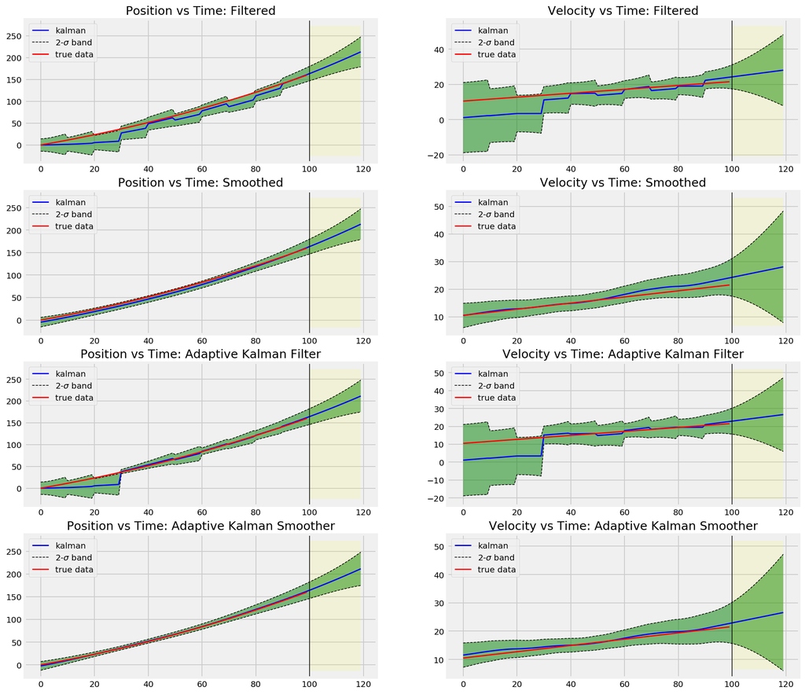

```python
fig = plt.figure(figsize=(15,30))

j = 0
j1 = 1
ax1 = fig.add_subplot(8, 2, 1)
plot_kalman(ameans[:, j, :], acovs[:, j, j], afsmeans[:, j, :], afscovs[:, j, j], true[j], num_sigmas=2,
            ax=ax1, title="Position vs Time: Filtered")

ax2 = fig.add_subplot(8, 2, 2)
plot_kalman(ameans[:, j1, :], acovs[:, j1, j1], afsmeans[:, j1, :], afscovs[:, j1, j1], true[j1], num_sigmas=2,
            ax=ax2, title="Velocity vs Time: Filtered")

ax3 = fig.add_subplot(8, 2, 3)
plot_kalman(asmeans[:, j, :], ascovs[:, j, j], afsmeans[:, j, :], afscovs[:, j, j], true[j], num_sigmas=2,
            ax=ax3, title="Position vs Time: Smoothed")

ax4 = fig.add_subplot(8, 2, 4)
plot_kalman(asmeans[:, j1, :], ascovs[:, j1, j1], afsmeans[:, j1, :], afscovs[:, j1, j1], true[j1], num_sigmas=2,
            ax=ax4, title="Velocity vs Time: Smoothed")

ax5 = fig.add_subplot(8, 2, 5)
plot_kalman(aadmeans[:, j, :], aadcovs[:, j, j], aadfsmeans[:, j, :], aadfscovs[:, j, j], true[j], num_sigmas=2,
            ax=ax5, title="Position vs Time: Adaptive Kalman Filter")

ax6 = fig.add_subplot(8, 2, 6)
plot_kalman(aadmeans[:, j1, :], aadcovs[:, j1, j1], aadfsmeans[:, j1, :], aadfscovs[:, j1, j1], true[j1], num_sigmas=2,
            ax=ax6, title="Velocity vs Time: Adaptive Kalman Filter")

ax7 = fig.add_subplot(8, 2, 7)
plot_kalman(aadsmeans[:, j, :], aadscovs[:, j, j], aadfsmeans[:, j, :], aadfscovs[:, j, j], true[j], num_sigmas=2,
            ax=ax7, title="Position vs Time: Adaptive Kalman Smoother")

ax8 = fig.add_subplot(8, 2, 8)
plot_kalman(aadsmeans[:, j1, :], aadscovs[:, j1, j1], aadfsmeans[:, j1, :], aadfscovs[:, j1, j1], true[j1], num_sigmas=2,
            ax=ax8, title="Velocity vs Time: Adaptive Kalman Smoother")

plt.show()
```

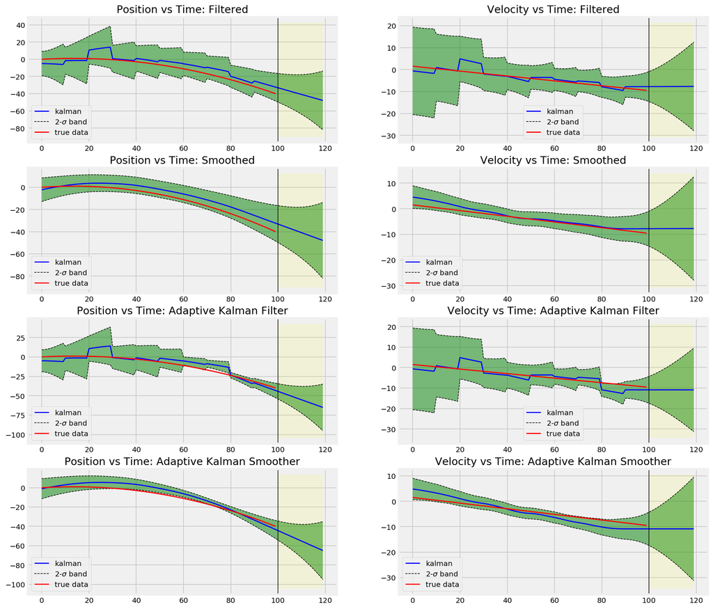

```python
fig = plt.figure(figsize=(15,30))

j = 3
j1 = 4
ax1 = fig.add_subplot(8, 2, 1)
plot_kalman(ameans[:, j, :], acovs[:, j, j], afsmeans[:, j, :], afscovs[:, j, j], true[j], num_sigmas=2,
            ax=ax1, title="Position vs Time: Filtered")

ax2 = fig.add_subplot(8, 2, 2)
plot_kalman(ameans[:, j1, :], acovs[:, j1, j1], afsmeans[:, j1, :], afscovs[:, j1, j1], true[j1], num_sigmas=2,
            ax=ax2, title="Velocity vs Time: Filtered")

ax3 = fig.add_subplot(8, 2, 3)
plot_kalman(asmeans[:, j, :], ascovs[:, j, j], afsmeans[:, j, :], afscovs[:, j, j], true[j], num_sigmas=2,
            ax=ax3, title="Position vs Time: Smoothed")

ax4 = fig.add_subplot(8, 2, 4)
plot_kalman(asmeans[:, j1, :], ascovs[:, j1, j1], afsmeans[:, j1, :], afscovs[:, j1, j1], true[j1], num_sigmas=2,
            ax=ax4, title="Velocity vs Time: Smoothed")

ax5 = fig.add_subplot(8, 2, 5)
plot_kalman(aadmeans[:, j, :], aadcovs[:, j, j], aadfsmeans[:, j, :], aadfscovs[:, j, j], true[j], num_sigmas=2,
            ax=ax5, title="Position vs Time: Adaptive Kalman Filter")

ax6 = fig.add_subplot(8, 2, 6)
plot_kalman(aadmeans[:, j1, :], aadcovs[:, j1, j1], aadfsmeans[:, j1, :], aadfscovs[:, j1, j1], true[j1], num_sigmas=2,
            ax=ax6, title="Velocity vs Time: Adaptive Kalman Filter")

ax7 = fig.add_subplot(8, 2, 7)
plot_kalman(aadsmeans[:, j, :], aadscovs[:, j, j], aadfsmeans[:, j, :], aadfscovs[:, j, j], true[j], num_sigmas=2,
            ax=ax7, title="Position vs Time: Adaptive Kalman Smoother")

ax8 = fig.add_subplot(8, 2, 8)
plot_kalman(aadsmeans[:, j1, :], aadscovs[:, j1, j1], aadfsmeans[:, j1, :], aadfscovs[:, j1, j1], true[j1], num_sigmas=2,
            ax=ax8, title="Velocity vs Time: Adaptive Kalman Smoother")

plt.show()
```

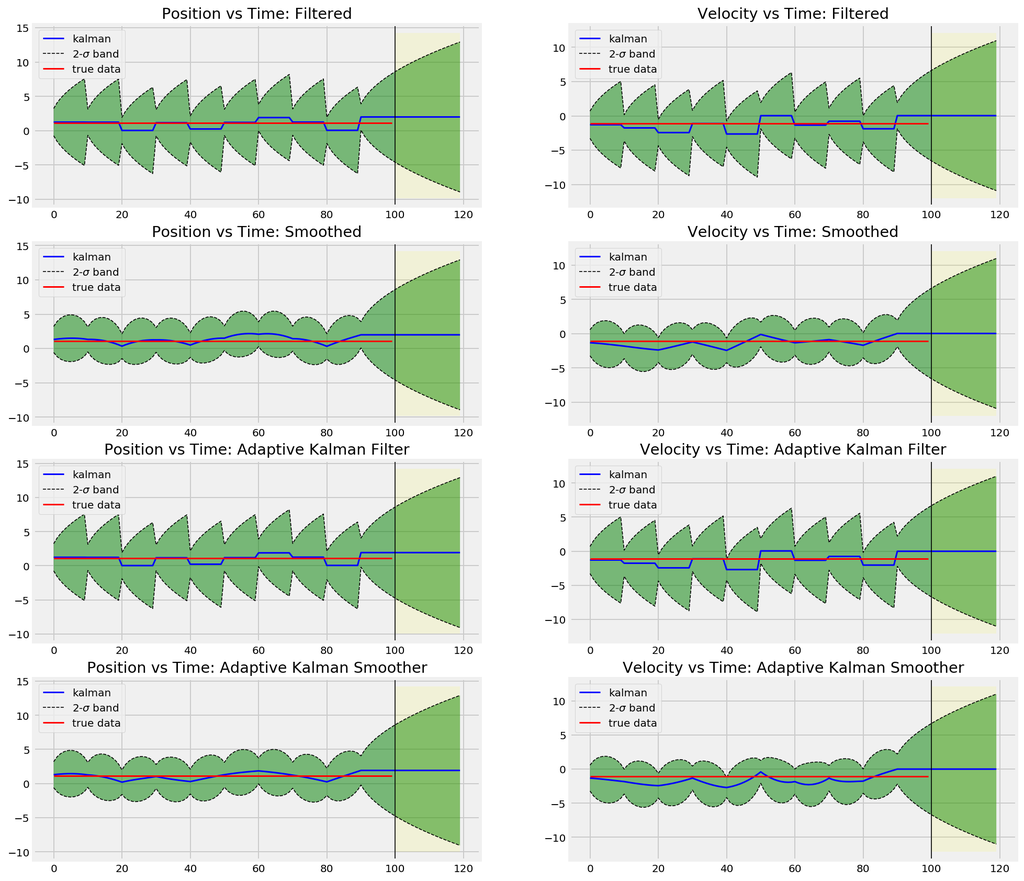

```python
fig = plt.figure(figsize=(15,30))

j = 2
j1 = 5
ax1 = fig.add_subplot(8, 2, 1)
plot_kalman(ameans[:, j, :], acovs[:, j, j], afsmeans[:, j, :], afscovs[:, j, j], true[j], num_sigmas=2,
            ax=ax1, title="Position vs Time: Filtered")

ax2 = fig.add_subplot(8, 2, 2)
plot_kalman(ameans[:, j1, :], acovs[:, j1, j1], afsmeans[:, j1, :], afscovs[:, j1, j1], true[j1], num_sigmas=2,
            ax=ax2, title="Velocity vs Time: Filtered")

ax3 = fig.add_subplot(8, 2, 3)
plot_kalman(asmeans[:, j, :], ascovs[:, j, j], afsmeans[:, j, :], afscovs[:, j, j], true[j], num_sigmas=2,
            ax=ax3, title="Position vs Time: Smoothed")

ax4 = fig.add_subplot(8, 2, 4)
plot_kalman(asmeans[:, j1, :], ascovs[:, j1, j1], afsmeans[:, j1, :], afscovs[:, j1, j1], true[j1], num_sigmas=2,
            ax=ax4, title="Velocity vs Time: Smoothed")

ax5 = fig.add_subplot(8, 2, 5)
plot_kalman(aadmeans[:, j, :], aadcovs[:, j, j], aadfsmeans[:, j, :], aadfscovs[:, j, j], true[j], num_sigmas=2,
            ax=ax5, title="Position vs Time: Adaptive Kalman Filter")

ax6 = fig.add_subplot(8, 2, 6)
plot_kalman(aadmeans[:, j1, :], aadcovs[:, j1, j1], aadfsmeans[:, j1, :], aadfscovs[:, j1, j1], true[j1], num_sigmas=2,
            ax=ax6, title="Velocity vs Time: Adaptive Kalman Filter")

ax7 = fig.add_subplot(8, 2, 7)
plot_kalman(aadsmeans[:, j, :], aadscovs[:, j, j], aadfsmeans[:, j, :], aadfscovs[:, j, j], true[j], num_sigmas=2,
            ax=ax7, title="Position vs Time: Adaptive Kalman Smoother")

ax8 = fig.add_subplot(8, 2, 8)
plot_kalman(aadsmeans[:, j1, :], aadscovs[:, j1, j1], aadfsmeans[:, j1, :], aadfscovs[:, j1, j1], true[j1], num_sigmas=2,
            ax=ax8, title="Velocity vs Time: Adaptive Kalman Smoother")

plt.show()
```

## Comparing Kalman Gains

```python
class KFKalmanGain(PlainKalmanFilter):
    """ In addition, calculates Kalman gain."""
    def __init__(self, x, Sigma, A, G, Q, R, B=None, u=None):
        super().__init__(x, Sigma, A, G, Q, R, B, u)

    def filter_state(self, y, x, Sigma, calc_kg=False):
        """ Updates/filters (x, Sigma) to posterior moments based on a current single measurement y_t."""
        assert (y.shape == (self.n_obs, 1))
        assert (x.shape == (self.n_states, 1))
        assert (Sigma.shape == (self.n_states, self.n_states))
        z = y - np.dot(self.G, x)                              # innovation or observation residual
        S = np.dot(self.G, np.dot(Sigma, self.G.T)) + self.R   # innovation or residual covariance
        SI = np.linalg.pinv(S)
        K = np.dot(Sigma, np.dot(self.G.T, SI))                # optimal Kalman gain
        x_post = x + np.dot(K, z)                              # updated (a posteriori) state estimate
        Sigma_post = Sigma - np.dot(K, np.dot(self.G, Sigma))  # updated (a posteriori) covariance estimate
        if calc_kg:
            return x_post, Sigma_post, K
        return x_post, Sigma_post


    def filter(self, y, calc_kg=False):
        """ Performs sequential state update followed by measurement update.
        Returns all {x_t}, {Sigma_t} given data {y_t}."""
        assert (y.shape[0] == self.n_obs)
        means = []
        covs = []
        kgain = []
        xp, Sigmap = self.x, self.Sigma
        for i, yi in enumerate(y.T):
            obs = np.atleast_2d(yi).reshape(self.n_obs, 1)
            xp, Sigmap = self.predict_next_state(xp, Sigmap)
            if calc_kg:
                xp, Sigmap, K = self.filter_state(obs, xp, Sigmap, calc_kg=True)
                kgain.append(K)
            xp, Sigmap = self.filter_state(obs, xp, Sigmap)
            means.append(xp)
            covs.append(Sigmap)
        if calc_kg:
            return np.array(means), np.array(covs), np.array(kgain)
        return np.array(means), np.array(covs)
```

```python
class AsyncKFKalmanGain(PlainKalmanFilter):
    """ In addition, calculates Kalman gain."""
    def __init__(self, x, Sigma, A, G, Q, R, GPS, B=None, u=None):
        super().__init__(x, Sigma, A, G, Q, R, B, u)
        self.GPS = GPS

    def filter_state(self, y, x, Sigma, calc_kg=False):
        """ Updates/filters (x, Sigma) to posterior moments based on a current single measurement y_t."""
        assert (y.shape == (self.n_obs, 1))
        assert (x.shape == (self.n_states, 1))
        assert (Sigma.shape == (self.n_states, self.n_states))
        z = y - np.dot(self.G, x)                              # innovation or observation residual
        S = np.dot(self.G, np.dot(Sigma, self.G.T)) + self.R   # innovation or residual covariance
        SI = np.linalg.pinv(S)
        K = np.dot(Sigma, np.dot(self.G.T, SI))                # optimal Kalman gain
        x_post = x + np.dot(K, z)                              # updated (a posteriori) state estimate
        Sigma_post = Sigma - np.dot(K, np.dot(self.G, Sigma))  # updated (a posteriori) covariance estimate
        if calc_kg:
            return x_post, Sigma_post, K
        return x_post, Sigma_post

    def filter(self, y, calc_kg=False):
        """ Performs sequential state update followed by measurement update
        if GPS signal/data is available.
        GPS is a boolean array of same length as y.
        Returns all {x_t}, {Sigma_t} given data {y_t}."""
        assert (y.shape[0] == self.n_obs)
        assert (y.shape[1] == self.GPS.shape[0])
        means = []
        covs = []
        kgain = []
        xp, Sigmap = self.x, self.Sigma
        for i, yi in enumerate(y.T):
            obs = np.atleast_2d(yi).reshape(self.n_obs, 1)
            xp, Sigmap = self.predict_next_state(xp, Sigmap)
            if self.GPS[i]:
                if calc_kg:
                    xp, Sigmap, K = self.filter_state(obs, xp, Sigmap, calc_kg=True)
                xp, Sigmap = self.filter_state(obs, xp, Sigmap)
            means.append(xp)
            covs.append(Sigmap)
            if calc_kg:
                kgain.append(K)
        if calc_kg:
            return np.array(means), np.array(covs), np.array(kgain)
        return np.array(means), np.array(covs)
```

```python
kf = KalmanFilter(initial_state_mean=x_0.T.tolist()[0],
                  initial_state_covariance=Sigma_0,
                  transition_matrices=A,
                  transition_covariance=Q,
                  observation_matrices=G,
                  observation_covariance=R)

# kf = KalmanFilter(transition_matrices=A, observation_matrices=G)
# kf = kf.em(measurements, n_iter=n_iter)

(filtered_state_means, filtered_state_covariances) = kf.filter(y.T.tolist())
(smoothed_state_means, smoothed_state_covariances) = kf.smooth(y.T.tolist())
```

```python
pkf = KFKalmanGain(x_0, Sigma_0, A, G, Q, R, B, u)
print(pkf)

xc, Sigmac = x_0, Sigma_0
means, covs, kgain = pkf.filter(y, calc_kg=True)
```

```
KFKalmanGain(x[(6, 1)], Sigma[(6, 6)], A[(6, 6)], G[(4, 6)], Q[(6, 6)], R[(4, 4)])
```

```python
apkf = AsyncKFKalmanGain(x_0, Sigma_0, A, G, Q, R, GPS, B, u)
print(apkf)

xc, Sigmac = x_0, Sigma_0
ameans, acovs, akgain = apkf.filter(y, calc_kg=True)
```

```
AsyncKFKalmanGain(x[(6, 1)], Sigma[(6, 6)], A[(6, 6)], G[(4, 6)], Q[(6, 6)], R[(4, 4)])
```

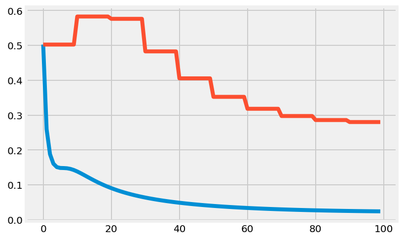

```python
plt.plot(kgain[:, 0, 0])
plt.plot(akgain[:, 0, 0])
```

[figure not shown]

```python
plt.plot(kgain[:, 3, 1])
plt.plot(akgain[:, 3, 1])
```

```python
error1 = [(means[:,i,0] - true[i]).std() for i in range(6)]
error2 = [(ameans[:,i,0] - true[i]).std() for i in range(6)]
error3 = [(filtered_state_means[:,i] - true[i]).std() for i in range(6)]
```

```python
error1, error2, error3
```

```
([5.752403919916126,
  4.564926976855165,
  0.7614305905694219,
  7.287586132805421,
  3.4499481800949017,
  0.7645627165612351],
 [6.823201330084938,
  4.365975243635533,
  0.7041836406773068,
  5.75413542843758,
  2.375148000415093,
  0.9152599413754174],
 [5.744062443763014,
  4.5239946427197,
  0.6635358915822085,
  7.101355743661591,
  3.1170800704640724,
  0.6696553957206384])
```

Another interesting application of extended Kalman filter on GPS data can be found [here](https://github.com/balzer82/Kalman/blob/master/Extended-Kalman-Filter-CTRA.ipynb)

# Application to GPS Signals

```python
import gpxpy
import pandas as pd
import mplleaflet
# from pykalman import KalmanFilter


with open('../data/gps_track.gpx', 'r') as fh:
    gpx_file = gpxpy.parse(fh)

segment = gpx_file.tracks[1].segments[0]
coords = pd.DataFrame([
    {'lat': p.latitude,
     'lon': p.longitude,
     'ele': p.elevation,
     'time': p.time} for p in segment.points])
coords.set_index('time', drop=True, inplace=True)
coords.head()
```

| time | ele | lat | lon |
| --- | --- | --- | --- |
| 2010-08-05 14:23:59+00:00 | 542.320923 | 45.772175 | 14.357659 |
| 2010-08-05 14:25:08+00:00 | 550.972656 | 45.772090 | 14.357567 |
| 2010-08-05 14:26:36+00:00 | 553.856689 | 45.772064 | 14.357461 |
| 2010-08-05 14:26:46+00:00 | 555.779297 | 45.772003 | 14.357343 |
| 2010-08-05 14:26:56+00:00 | 555.779297 | 45.771906 | 14.357355 |

```python
rate = 2

fig = plt.figure()
plt.rcParams['figure.figsize'] = (14,12)
plt.plot(coords['lon'].values[::rate], coords['lat'].values[::rate], 'r-o', linewidth=0.5);
mplleaflet.display(fig=fig)
```

[interactive chart not shown]

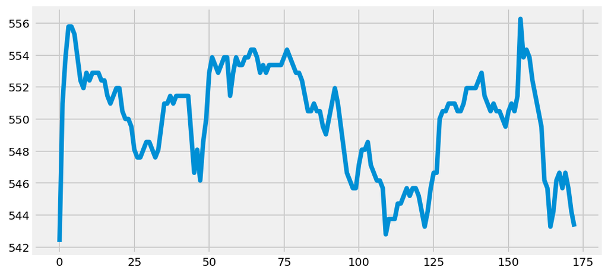

```python
plt.rcParams['figure.figsize'] = (8,4)
plt.plot(coords['ele'].values);
```

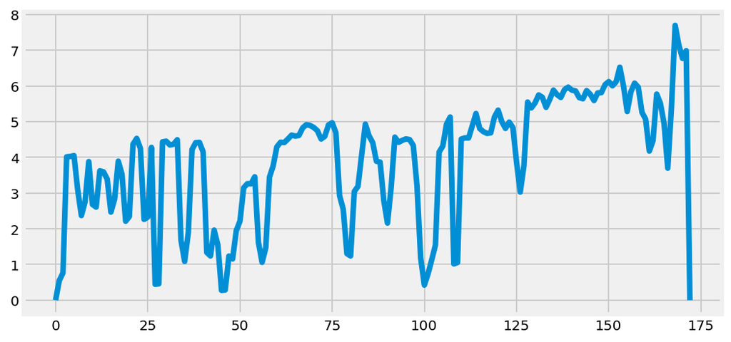

```python
segment.points[0].speed, segment.points[-1].speed = 0.0, 0.0
gpx_file.add_missing_speeds()
speed = np.array([p.speed for p in segment.points]) * 3.6
plt.plot(speed);
```

```python
segment.get_uphill_downhill()
```

```
UphillDownhill(uphill=50.0361555999998, downhill=49.07497459999979)
```

## Modeling the State Dynamics Equation

Let's choose our state to be: $x = (x_1, x_2, x_3, v_1, v_2, v_3)$, and dynamics to be governed by non accelerating motion:

- $x_{t+1} = x_t + v_t dt + w_t$
- $v_{t+1} = v_t + w'_t$

We will measure $(x_1, x_2, x_3)$, and our measurement equation would be:

- $y_t = G x_t + u_t$

```python
dt = 1  # sampling rate
x_0 = np.zeros((6, 1))

A = np.eye(6)
A[:3,3:] = dt * np.eye(3)

G = np.zeros((3, 6))
G[:3,:3] = np.eye(3)

R = np.diag([1e-4, 1e-4, 100]) ** 2  # approximate GPS errors
```

```python
# Make time samples equidistant and equal to 1 sec

coords.index = np.round(coords.index.astype(np.int64), -9).astype('datetime64[ns]')

# We fix signal loss by resampling

coords = coords.resample('1S').asfreq()
coords.loc[coords.ele.isnull()].head()
```

| time | ele | lat | lon |
| --- | --- | --- | --- |
| 2010-08-05 14:24:00 | NaN | NaN | NaN |
| 2010-08-05 14:24:01 | NaN | NaN | NaN |
| 2010-08-05 14:24:02 | NaN | NaN | NaN |
| 2010-08-05 14:24:03 | NaN | NaN | NaN |
| 2010-08-05 14:24:04 | NaN | NaN | NaN |

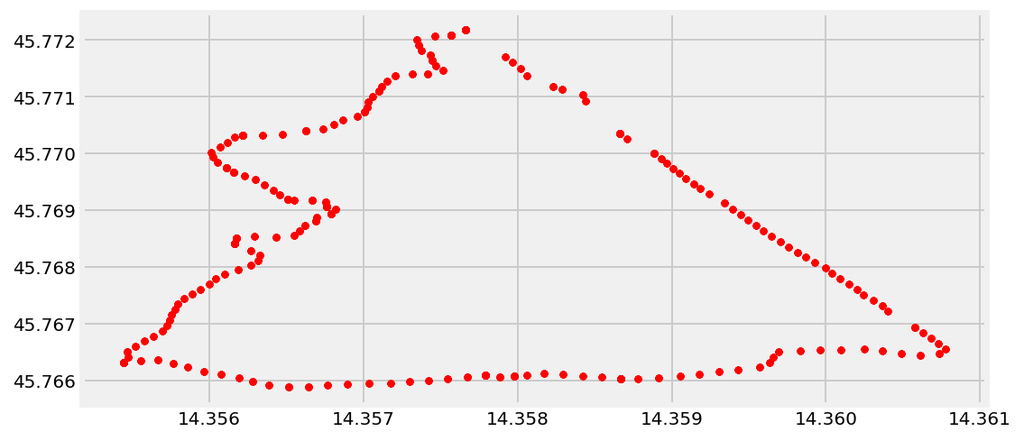

```python
# missing values should be masked for Kalman filter
measurements = np.ma.masked_invalid(coords[['lon', 'lat', 'ele']].values)

initial_state_mean = np.hstack([measurements[0, :], 3*[0.0]])
initial_state_covariance = np.diag([1e-4, 1e-4, 50, 1e-6, 1e-6, 1e-6]) ** 2

plt.plot(measurements[:,0], measurements[:,1])
filled_coords = coords.fillna(method='pad').ix[coords.ele.isnull()]
plt.plot(filled_coords['lon'].values, filled_coords['lat'].values, 'r.');
```

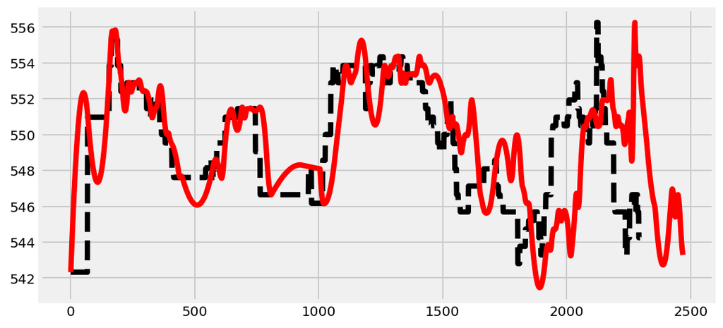

```python
kf = KalmanFilter(transition_matrices=A,
                 observation_matrices=G,
                 observation_covariance=R,
                 initial_state_mean=initial_state_mean,
                 initial_state_covariance=initial_state_covariance,
                 em_vars=['transition_covariance'])

kf = kf.em(measurements, n_iter=100)
state_means, state_vars = kf.smooth(measurements)

plt.plot(filled_coords['ele'].values, 'k--')
plt.plot(state_means[:,2], 'r-')
plt.show()
```

After getting the smoothed data

```python
coords.shape, state_means.shape
```

```
((2470, 3), (2470, 6))
```

```python
coords.ix[:, ['lon', 'lat', 'ele']] = state_means[:,:3]
coords = coords.reset_index()
orig_coords = coords.ix[~coords.index.isnull()]#.set_index('idx')

for i, p in enumerate(segment.points):
    p.speed = None
    p.elevation = orig_coords.at[i, 'ele']
    p.longitude = orig_coords.at[i, 'lon']
    p.latitude = orig_coords.at[i, 'lat']

segment.get_uphill_downhill()
```

```
UphillDownhill(uphill=18.44492906137782, downhill=5.008903455471341)
```

# (Naive) Applications to Stock Returns

```python
import pandas as pd
from bokeh.plotting import figure, show, output_notebook
from nsepy import get_history
from datetime import date, datetime
from sklearn.metrics import roc_curve
from sklearn.metrics import roc_auc_score

def plot_roc_curve(fpr, tpr, auc):
    plt.plot(fpr, tpr, color='orange', label='ROC AUC: %.2f' % auc)
    plt.plot([0, 1], [0, 1], color='darkblue', linestyle='--')
    plt.xlabel('False Positive Rate')
    plt.ylabel('True Positive Rate')
    plt.title('Receiver Operating Characteristic (ROC) Curve')
    plt.legend()
    plt.show()
```

### Simple Kalman Filter for Stock Returns

```python
df = get_history(symbol='TCS', start = date(2019,1,1), end = date(2019,5,25))
returns = 100 * df[['Close']].pct_change().dropna().values
```

```python
n = returns.shape[0]
n_train = int(0.75*n)
r_train, r_test = returns[:n_train], returns[n_train:]
r = returns
```

```python
# arguments are: x_0, Sigma_0, A, G, Q, R
pkf = PlainKalmanFilter(r[0,0].reshape(-1,1), np.atleast_2d([0.1]), np.atleast_2d([1]),
                        np.atleast_2d([1]), np.atleast_2d([0.1]), np.atleast_2d([1]))
y = r.reshape(1, -1)
means, covs = pkf.filter(y)
```

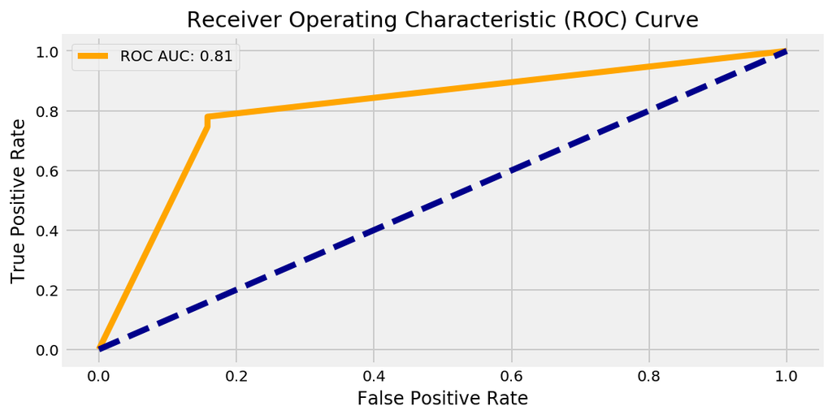

```python
fpr, tpr, thresholds = roc_curve(np.sign(means.ravel()), np.sign(r.ravel()))
auc = roc_auc_score(np.sign(means.ravel()), np.sign(r.ravel()))
plot_roc_curve(fpr, tpr, auc)
```

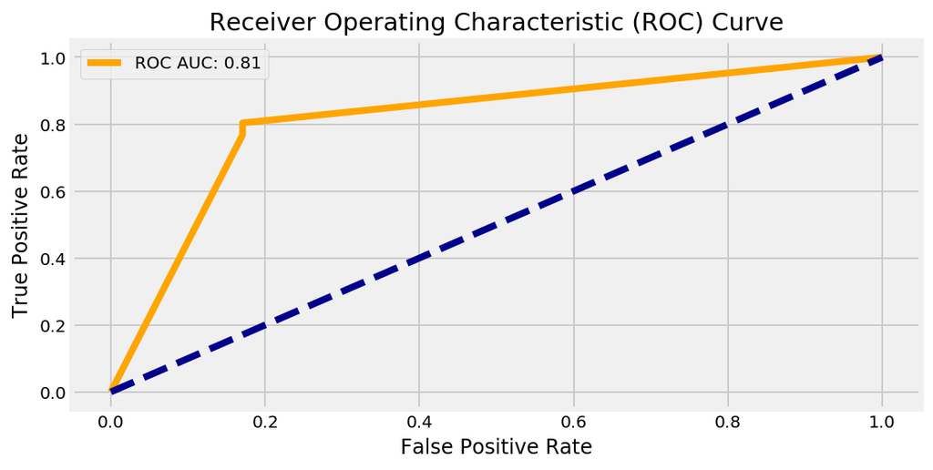

```python
kf = KalmanFilter(transition_matrices = [1],
                  observation_matrices = [1],
                  initial_state_mean = r[0],
                  initial_state_covariance = 0.1,
                  observation_covariance=0.1,
                  transition_covariance=.01)

# kf = KalmanFilter(initial_state_mean = r[0], transition_matrices = [1], observation_matrices = [1])
# kf = kf.em(returns, n_iter=20)

state_means,_ = kf.filter(y)
state_means = state_means.flatten()

fpr, tpr, thresholds = roc_curve(np.sign(state_means), np.sign(y.ravel()))
auc = roc_auc_score(np.sign(state_means), np.sign(y.ravel()))
plot_roc_curve(fpr, tpr, auc)
```

## Kalman instead of MA/EMA

```python
df["date"] = pd.to_datetime(df.index)

mids = (df.Open + df.Close)/2
spans = abs(df.Close-df.Open)

inc = df.Close > df.Open
dec = df.Open > df.Close
w = 12*60*60*1000 # half day in ms

prices = df[['Close']].dropna().values

# arguments are: x_0, Sigma_0, A, G, Q, R
pkf = PlainKalmanFilter(np.atleast_2d([prices[0,0]]), np.atleast_2d([0.01]), np.atleast_2d([1]),
                        np.atleast_2d([1]), np.atleast_2d([0.01]), np.atleast_2d([0.1]))
print(pkf)

price_state_means,_ = pkf.filter(prices.T)
price_state_means = price_state_means.flatten()
sprice_state_means,_ = pkf.smooth(prices.T)
sprice_state_means = sprice_state_means.flatten()
```

```
PlainKalmanFilter(x[(1, 1)], Sigma[(1, 1)], A[(1, 1)], G[(1, 1)], Q[(1, 1)], R[(1, 1)])
```

```python
output_notebook()

TOOLS = "pan,wheel_zoom,box_zoom,reset,save"

p = figure(x_axis_type="datetime", tools=TOOLS, plot_width=900, toolbar_location="left", y_axis_label = "Price",
          x_axis_label = "Date", y_range=(1800, 2400))

p.segment(df.date, df.High, df.date, df.Low, color="black")
p.rect(df.date[inc], mids[inc], w, spans[inc], fill_color='green', line_color="green")
p.rect(df.date[dec], mids[dec], w, spans[dec], fill_color='red', line_color="red")
p.line(df.date, price_state_means, line_width=2.2, line_color = 'blue', legend="Kalman filter")
p.line(df.date, sprice_state_means, line_width=1.8, line_color = 'cyan', legend="Kalman smoother")
p.xaxis.major_label_orientation = np.pi/4
p.grid.grid_line_alpha=0.3
show(p)
```

[interactive chart not shown]

### Sequential Prediction

```python
kfall = KalmanFilter(transition_matrices = [1],
              observation_matrices = [1],
              initial_state_mean = returns[0],
              initial_state_covariance = 0.01,
              observation_covariance=0.1,
              transition_covariance=.01)

meansall, covariancesall = kfall.filter(returns)
```

```python
window = 1
pred = []
cov_0 = 0.01
mean_0 = returns[0,0]

for i in range(window, returns.shape[0]):
    obs = returns[:i]
    kf = KalmanFilter(transition_matrices = [1],
                  observation_matrices = [1],
                  initial_state_mean = obs[-1],
                  initial_state_covariance = cov_0,
                  observation_covariance=0.1,
                  transition_covariance=.01)

    means, covariances = kf.smooth(obs)
    mean_0, cov_0 = means[-1], covariances[-1]
    p, _ = kf.sample(1, mean_0)
    pred.append(p)

pred = np.array(pred).ravel()
```

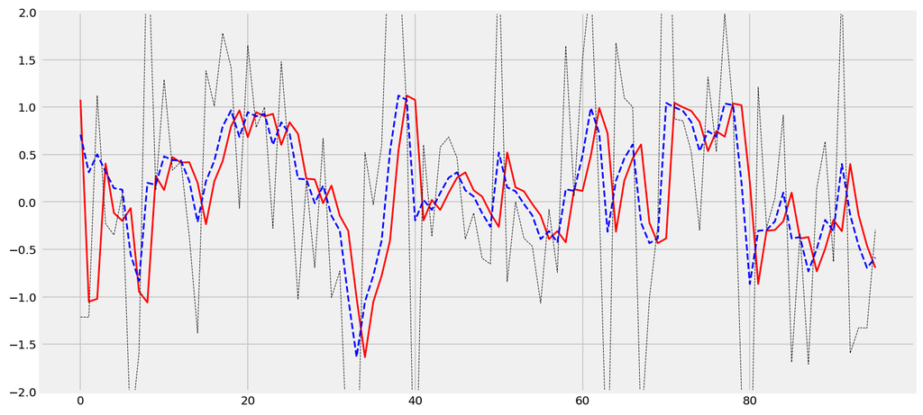

```python
plt.figure(figsize=(12, 6))
plt.plot(pred.ravel(), 'r', linewidth=1.5)
plt.plot(returns[window:].ravel(), 'k--', linewidth=0.5)
plt.plot(meansall[window:].ravel(), 'b--', linewidth=1.5)
plt.ylim(-2, 2);
```

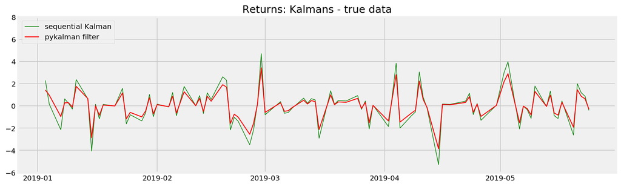

```python
fig = plt.figure(figsize=plt.figaspect(0.3))

ax = fig.add_subplot(1, 1, 1)
ax.plot(df.index[window+1:], pred.ravel()-returns[window:].ravel(), 'g-', linewidth=0.8, label="sequential Kalman")
ax.plot(df.index[window+1:], state_means[window:].ravel()-returns[window:].ravel(), 'r-', linewidth=1.2, label="pykalman filter")
ax.set_ylim([-6, 8])
ax.legend(loc="upper left")
ax.set_title("Returns: Kalmans - true data")

plt.show()
```

```python
# fraction of matches between signs of predicted and actial returns
hit_score = np.sum(np.sign(np.array(pred.ravel())) == np.sign(returns[window:].ravel()))/len(pred.ravel())
print("hit score:", hit_score)
```

```
hit score: 0.53125
```

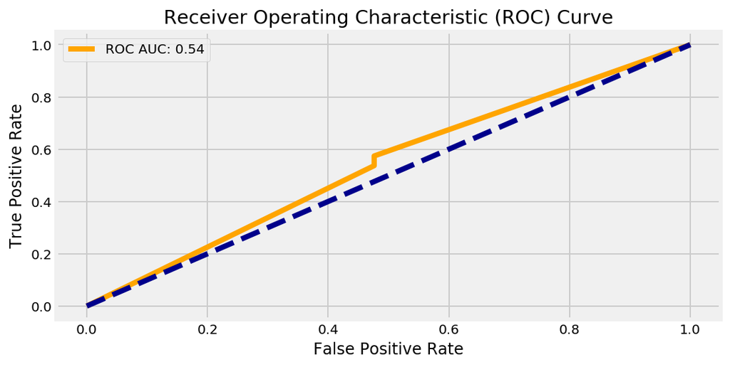

```python
fpr, tpr, thresholds = roc_curve(np.sign(np.array(pred.ravel())), np.sign(returns[window:].ravel()))
auc = roc_auc_score(np.sign(np.array(pred.ravel())), np.sign(returns[window:].ravel()))
plot_roc_curve(fpr, tpr, auc)
```

# Using Kalman Filter for Linear Regression

Assume that the hidden state $x = [b, a]$ is a line, $(b z + a)$, that observations, $y$, follow. Our initial guess for state mean and covariance are: $\hat{x}_0 = [0, 0]$ and $\Sigma_0 = 1_{2\times 2}$. We also assume that our parameters follow a random walk, therefore, transition matrix is the identity, $A=1$, and transition covariance is a small number times the identity, $Q \propto 1_{2 \times 2}$.

Part of this material is taken from [Quantopian Lecture Series: Kalman Filters](https://www.quantopian.com/research/notebooks/Cloned%20from%20%22Quantopian%20Lecture%20Series%3A%20Kalman%20Filters%22%202.ipynb)

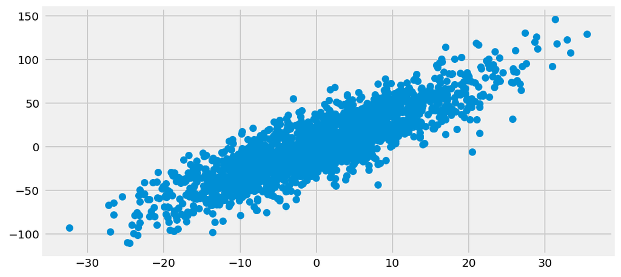

```python
a = 1.3
b = 3.2
N = 2000
sigma_y = 20

z = 10 * np.random.randn(N)
y = b * z + a + sigma_y * np.random.randn(N)

plt.scatter(z, y)
```

```python
delta = 1e-3
trans_cov = delta / (1 - delta) * np.eye(2) # How much random walk wiggles
obs_mat = np.expand_dims(np.vstack([[z], [np.ones(len(z))]]).T, axis=1)
```

```python
kf = KalmanFilter(n_dim_obs=1, n_dim_state=2, # y is 1-dimensional, (alpha, beta) is 2-dimensional
                  initial_state_mean=[0, 0],
                  initial_state_covariance=np.ones((2, 2)),
                  transition_matrices=np.eye(2),
                  observation_matrices=obs_mat,
                  observation_covariance=sigma_y ** 2,
                  transition_covariance=trans_cov)

# Use the observations y to get running estimates and errors for the state parameters
state_means, state_covs = kf.filter(y)
smoothed_state_means, smoothed_state_covs = kf.smooth(y)
```

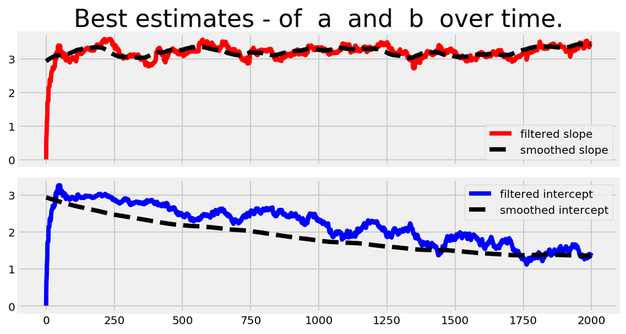

```python
tt = np.arange(N)

_, axarr = plt.subplots(2, sharex=True)
axarr[0].plot(tt, state_means[:,0], 'r', label='filtered slope')
axarr[0].plot(tt, smoothed_state_means[:,0], 'k--', label='smoothed slope')
axarr[0].legend()
axarr[1].plot(tt, state_means[:,1], 'b', label='filtered intercept')
axarr[1].plot(tt, smoothed_state_means[:,1], 'k--', label='smoothed intercept')
axarr[1].legend()
plt.tight_layout()
axarr[0].set_title("Best estimates - of  a  and  b  over time.", fontsize=22)
plt.show()
```

### Same with EM

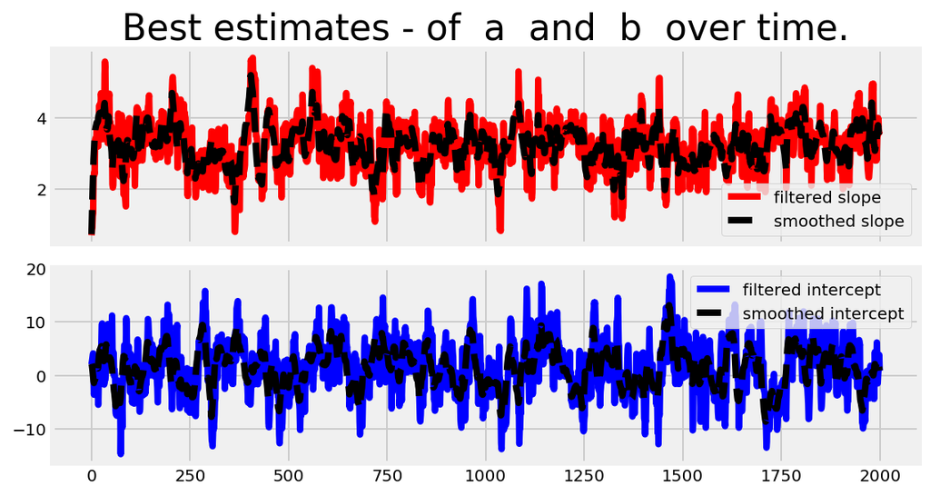

```python
kf = KalmanFilter(transition_matrices=np.eye(2),
                  observation_matrices=obs_mat)

kf = kf.em(y, n_iter=40)
state_means, state_covs = kf.filter(y)
smoothed_state_means, smoothed_state_covs = kf.smooth(y)

tt = np.arange(N)

_, axarr = plt.subplots(2, sharex=True)
axarr[0].plot(tt, state_means[:,0], 'r', label='filtered slope')
axarr[0].plot(tt, smoothed_state_means[:,0], 'k--', label='smoothed slope')
axarr[0].legend()
axarr[1].plot(tt, state_means[:,1], 'b', label='filtered intercept')
axarr[1].plot(tt, smoothed_state_means[:,1], 'k--', label='smoothed intercept')
axarr[1].legend()
plt.tight_layout()
axarr[0].set_title("Best estimates - of  a  and  b  over time.", fontsize=22)
plt.show()
```

### Convert jupyter notebook into the html file with in a given format

```python
notebook_file = r"TS1_Kalman_Filter.ipynb"
html_converter(notebook_file)
```